# 📖 Prediction

🧪 Data Setup

- 📥 Load Dataset
- 📊 Data Characteristics Dictionary
- 🔎 EDA
  - 📐 Linearity - LR Assumption
  - 📉 Homoscedasticity - LR Assumption
  - 📊 Normality of Residuals - LR Assumption
  - 🔗 Multicollinearity - LR Assumption
  - 🔄 Independence of Residuals - LR Assumption
- 🛠️ Feature Engineering
- 🧹 Preprocessing

🧪 Baseline Model

- 🆚 Predicted vs Actual
- 🌀 Residual Plot
- 📏 Evaluation Metrics
- 🧮 Update Best Model Info

🧰 Algorithms

- ⚙️ Linear Regression
- 🧊 Ridge Regression
- 🔥 Lasso Regression
- 🧃 ElasticNet
- 🌳 Decision Trees
- 🪵 Random Forests
- 🚀 Gradient Boosting (XGBoost, LightGBM)
- ⚙️ Support Vector Machines (SVR)
- 🧠 K-Nearest Neighbors (KNN)
- 🤖 Neural Networks (MLP Regressor)

📊 Model Selection

- 🧠 Recommend Models
- 📈 Model Comparison
- 📊 Feature Importance
- 🧬 SHAP Values

🎯 Fine Tune

- 🧪 Feature Selection – RFE
- 🧪 Feature Selection – RFE + SHAP
- 🧪 Grid Search
- 🎲 Randomized Search

📦 Ensemble Methods

- 🪵 Bagging
- 🚀 Boosting
- 🧠 Stacking (Meta-modeling)

📦 Export & Deployment

- 🧊 Pickling
- 📊 Monitoring Hooks

# 🧪 Data Setup

#### 📥 Load Dataset

**📖 Click to Expand**

- **MedInc**: Median income in block group
- **HouseAge**: Median house age in block group
- **AveRooms**: Average number of rooms per household
- **AveBedrms**: Average number of bedrooms per household
- **Population**: Block group population
- **AveOccup**: Average number of household members
- **Latitude**: Block group latitude
- **Longitude**: Block group longitude
- **Target**: Median house value (in $100,000s)

```python
from IPython.core.interactiveshell import InteractiveShell
InteractiveShell.ast_node_interactivity = "all"
```

```python
from sklearn.datasets import fetch_california_housing
import pandas as pd

# Load dataset
df = fetch_california_housing(as_frame=True).frame
target_col = 'MedHouseVal'

# Preview dataset
df.head()
```

|  | MedInc | HouseAge | AveRooms | AveBedrms | Population | AveOccup | Latitude | Longitude | MedHouseVal |
| --- | --- | --- | --- | --- | --- | --- | --- | --- | --- |
| 0 | 8.3252 | 41.0 | 6.984127 | 1.023810 | 322.0 | 2.555556 | 37.88 | -122.23 | 4.526 |
| 1 | 8.3014 | 21.0 | 6.238137 | 0.971880 | 2401.0 | 2.109842 | 37.86 | -122.22 | 3.585 |
| 2 | 7.2574 | 52.0 | 8.288136 | 1.073446 | 496.0 | 2.802260 | 37.85 | -122.24 | 3.521 |
| 3 | 5.6431 | 52.0 | 5.817352 | 1.073059 | 558.0 | 2.547945 | 37.85 | -122.25 | 3.413 |
| 4 | 3.8462 | 52.0 | 6.281853 | 1.081081 | 565.0 | 2.181467 | 37.85 | -122.25 | 3.422 |

#### 📊 Data Characteristics Dictionary

**📖 Click to Expand**

This section initializes the **data characteristics dictionary**, which will store various metadata about the dataset, including details about the target variable, features, data size, and relationships between features and the target.

The dictionary contains the following key sections:

1. **🎯 Target Variable**:
   - **Distribution**: Specifies whether the target variable has a **normal** or **skewed** distribution.
   - **Outliers**: Flag indicating if outliers are detected in the target variable (True or False).
2. **🔧 Features**:
   - **Type**: A dictionary specifying whether each feature is **categorical** or **continuous**.
   - **Correlation**: A dictionary indicating whether each feature is significantly correlated with the target variable (e.g., {"AveRooms": True, "HouseAge": False}).
   - **Multicollinearity**: Flag indicating whether there is high multicollinearity among features (True or False).
   - **Outliers**: A dictionary showing the number of outliers detected in each feature (e.g., {"AveRooms": 3, "HouseAge": 0}).
   - **Missing Data**: A dictionary indicating the percentage of missing data for each feature (e.g., {"AveRooms": 5.0, "Population": 2.5}).
3. **📈 Data Size**:
   - **Samples**: The number of rows (samples) in the dataset.
   - **Features**: The number of columns (features) in the dataset.
4. **🔍 Relationships**:
   - **Linear Relationships**: A dictionary that flags features with significant linear relationships (Pearson correlation > 0.7) with the target variable.
   - **Non-Linear Relationships**: A dictionary that flags features with non-linear relationships with the target variable.

This dictionary will be updated dynamically as we analyze the dataset. It serves as a **summary of key dataset properties** to guide further analysis and model selection decisions.

```python
# Initialize the data characteristics dictionary for prediction
data_characteristics = {
    "target_variable": {
        "distribution": None,  # Possible values: "normal", "skewed"
        "outliers": None  # Possible values: True (outliers detected in target variable), False (no outliers in target variable)
    },
    "features": {
        "type": None,  # Dictionary with feature names as keys and types as values ("categorical", "continuous")
        "correlation": None,  # Dictionary with feature names as keys and boolean values indicating whether they are significantly correlated with target (e.g., {"AveRooms": True, "HouseAge": False})
        "multicollinearity": None,  # Possible values: True (high multicollinearity detected), False (no multicollinearity)
        "outliers": None,  # Dictionary with feature names as keys and the number of outliers as values (e.g., {"AveRooms": 3, "HouseAge": 0})
        "missing_data": None  # Dictionary with feature names as keys and the percentage of missing data as values (e.g., {"AveRooms": 5.0, "Population": 2.5})
    },
    "data_size": {
        "samples": None,  # Number of rows (samples) in the dataset
        "features": None  # Number of columns (features) in the dataset
    },
    "relationships": {
        "feature_target_linear_relationships": {
            # Example: "AveRooms": True means there is a linear relationship between the feature 'AveRooms' and the target variable
        },
        "feature_target_non_linear_relationships": {
            # Example: "HouseAge": True means there is a non-linear relationship between the feature 'HouseAge' and the target variable
        }
    }
}
```

#### 🔎 EDA

```python
# Import necessary libraries
import numpy as np
import pandas as pd
from scipy import stats
from sklearn.preprocessing import LabelEncoder

# Assuming df is your dataset and target_col is your target column
# For example: target_col = 'MedHouseVal'

# 1. Populate Target Variable Characteristics
# ===========================================
# Distribution check (Target)
target_dist = df[target_col].describe()
if df[target_col].skew() > 1:
    data_characteristics["target_variable"]["distribution"] = "skewed"
elif df[target_col].skew() < -1:
    data_characteristics["target_variable"]["distribution"] = "skewed"
else:
    data_characteristics["target_variable"]["distribution"] = "normal"

# Check for outliers in the Target
z_scores_target = np.abs(stats.zscore(df[target_col]))
outliers_target = np.where(z_scores_target > 3)
data_characteristics["target_variable"]["outliers"] = len(outliers_target[0]) > 0  # True if outliers are present
```

```python
# 2. Populate Features Characteristics
# ====================================
# Initialize dictionaries for features
feature_types = {}
feature_correlations = {}
outliers_features = {}
missing_data_features = {}

# Feature Types and Correlations
for col in df.columns:
    if df[col].dtype == 'object':  # Categorical feature
        feature_types[col] = "categorical"
        # Encoding categorical variables
        le = LabelEncoder()
        df[col] = le.fit_transform(df[col])
    else:  # Continuous feature
        feature_types[col] = "continuous"

    # Correlation with the target (Pearson)
    if col != target_col:  # Don't check correlation for the target column itself
        corr_value = df[target_col].corr(df[col])
        feature_correlations[col] = abs(corr_value) > 0.3  # Flag if correlation is significant

    # Outliers detection (Z-score method)
    z_scores_feature = np.abs(stats.zscore(df[col]))
    feature_outliers = np.where(z_scores_feature > 3)  # Points with Z-score > 3 are outliers
    outliers_features[col] = len(feature_outliers[0])  # Store the number of outliers in the feature

    # Missing data calculation
    missing_data = df[col].isnull().sum() / len(df) * 100
    if missing_data > 0:
        missing_data_features[col] = missing_data  # Store percentage of missing data for each feature

# Update the dictionary with feature-related information
data_characteristics["features"]["type"] = feature_types
data_characteristics["features"]["correlation"] = feature_correlations
data_characteristics["features"]["outliers"] = outliers_features
data_characteristics["features"]["missing_data"] = missing_data_features
```

```python
# 3. Check for Multicollinearity
# =======================================
correlation_matrix = df.corr()
multicollinearity_flag = False
for i in range(len(correlation_matrix.columns)):
    for j in range(i):
        if abs(correlation_matrix.iloc[i, j]) > 0.9:
            multicollinearity_flag = True
            break
data_characteristics["features"]["multicollinearity"] = multicollinearity_flag
```

```python
# 4. Populate Data Size Characteristics
# ====================================
data_characteristics["data_size"]["samples"] = df.shape[0]
data_characteristics["data_size"]["features"] = df.shape[1]
```

```python
# 5. Populate Relationships between Features and Target
# =======================================================
linear_relationships = {}
non_linear_relationships = {}
for col in df.columns:
    if col != target_col:
        # Linear relationship check (Pearson correlation threshold of 0.7)
        corr_value = df[target_col].corr(df[col])
        if abs(corr_value) >= 0.7:
            linear_relationships[col] = True
            non_linear_relationships[col] = False
        else:
            linear_relationships[col] = False
            non_linear_relationships[col] = True

# Update the dictionary with the relationships
data_characteristics["relationships"]["feature_target_linear_relationships"] = linear_relationships
data_characteristics["relationships"]["feature_target_non_linear_relationships"] = non_linear_relationships
```

```python
from pprint import pprint
pprint(data_characteristics)
```

```
{'data_size': {'features': 9, 'samples': 20640},
 'features': {'correlation': {'AveBedrms': False,
                              'AveOccup': False,
                              'AveRooms': False,
                              'HouseAge': False,
                              'Latitude': False,
                              'Longitude': False,
                              'MedInc': True,
                              'Population': False},
              'missing_data': {},
              'multicollinearity': True,
              'outliers': {'AveBedrms': 145,
                           'AveOccup': 8,
                           'AveRooms': 133,
                           'HouseAge': 0,
                           'Latitude': 0,
                           'Longitude': 0,
                           'MedHouseVal': 0,
                           'MedInc': 345,
                           'Population': 342},
              'type': {'AveBedrms': 'continuous',
                       'AveOccup': 'continuous',
                       'AveRooms': 'continuous',
                       'HouseAge': 'continuous',
                       'Latitude': 'continuous',
                       'Longitude': 'continuous',
                       'MedHouseVal': 'continuous',
                       'MedInc': 'continuous',
                       'Population': 'continuous'}},
 'relationships': {'feature_target_linear_relationships': {'AveBedrms': False,
                                                           'AveOccup': False,
                                                           'AveRooms': False,
                                                           'HouseAge': False,
                                                           'Latitude': False,
                                                           'Longitude': False,
                                                           'MedInc': False,
                                                           'Population': False},
                   'feature_target_non_linear_relationships': {'AveBedrms': True,
                                                               'AveOccup': True,
                                                               'AveRooms': True,
                                                               'HouseAge': True,
                                                               'Latitude': True,
                                                               'Longitude': True,
                                                               'MedInc': True,
                                                               'Population': True}},
 'target_variable': {'distribution': 'normal', 'outliers': False}}
```

#### 📐 Linearity - LR Assumption

**📖 Click to Expand**

- The **linearity assumption** states that the relationship between each predictor and the outcome is linear.
- Violations mean the model may underfit or misestimate relationships.
- A common diagnostic is a **scatter plot of predicted values vs residuals** — if the pattern is random (no curve), linearity holds.
- You can also use **partial regression plots** or **added variable plots** to assess individual feature relationships.

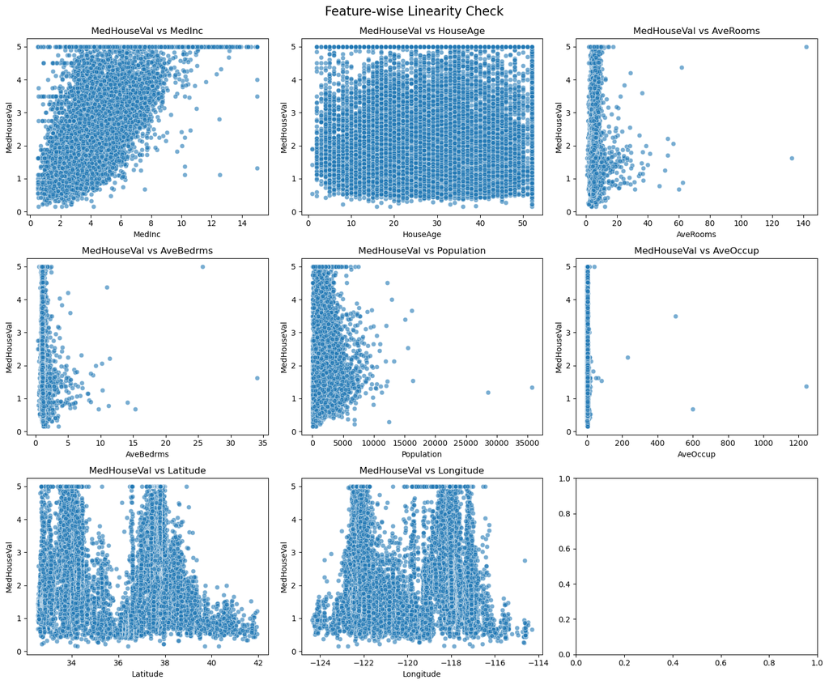

```python
import matplotlib.pyplot as plt
import seaborn as sns

# Define X and y using target_col
X = df.drop(columns=[target_col])
y = df[target_col]

# Plot each feature vs target
fig, axes = plt.subplots(nrows=3, ncols=3, figsize=(15, 12));
axes = axes.flatten();

for idx, col in enumerate(X.columns):
    sns.scatterplot(x=df[col], y=y, ax=axes[idx], alpha=0.6);
    axes[idx].set_title(f'{target_col} vs {col}');
    axes[idx].set_xlabel(col);
    axes[idx].set_ylabel(target_col);

plt.tight_layout();
plt.suptitle('Feature-wise Linearity Check', fontsize=16, y=1.02);
plt.show();
```

#### 📉 Homoscedasticity - LR Assumption

**📖 Click to Expand**

- **Homoscedasticity** means residuals have constant variance across all levels of predicted values.
- If variance increases or decreases with prediction size, you have **heteroscedasticity**.
- This violates OLS assumptions and leads to inefficient estimates.
- To detect it, plot **residuals vs predicted values** after model fit. A fan or cone shape indicates heteroscedasticity.

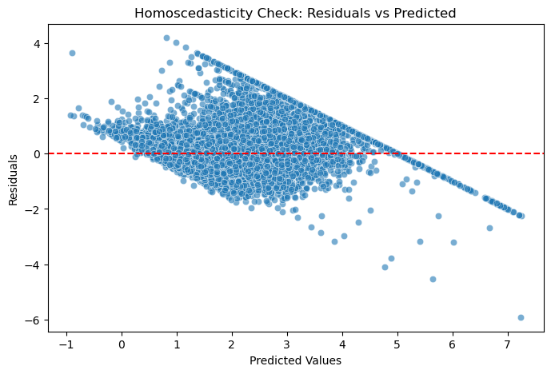

```python
from sklearn.linear_model import LinearRegression
from sklearn.model_selection import train_test_split

# Redefine X and y in case not done yet
X = df.drop(columns=[target_col])
y = df[target_col]

# Split and fit model
X_train, X_test, y_train, y_test = train_test_split(X, y, random_state=42)
lr = LinearRegression()
lr.fit(X_train, y_train)

# Get residuals
y_pred = lr.predict(X_train)
residuals = y_train - y_pred

# Plot residuals vs predicted
plt.figure(figsize=(8, 5));
sns.scatterplot(x=y_pred, y=residuals, alpha=0.6);
plt.axhline(0, linestyle='--', color='red');
plt.xlabel("Predicted Values");
plt.ylabel("Residuals");
plt.title("Homoscedasticity Check: Residuals vs Predicted");
plt.show();
```

#### 📊 Normality of Residuals - LR Assumption

**📖 Click to Expand**

- This assumption says that residuals (errors) should be **normally distributed**.
- It’s especially important when constructing **confidence intervals** or conducting **hypothesis tests** on coefficients.
- While model fit may still work with non-normal residuals, statistical inference will be less valid.
- We check this using:
  - A **histogram** or **KDE plot** of residuals
  - A **Q-Q plot** to compare against a theoretical normal distribution

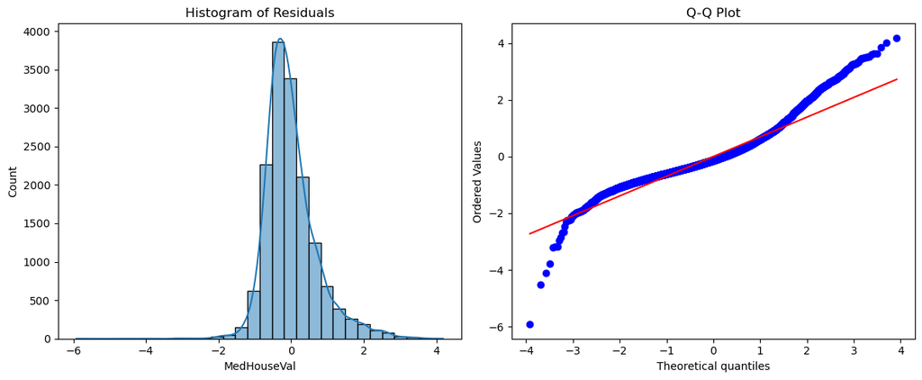

```python
import scipy.stats as stats

# Residuals already computed as: residuals = y_train - y_pred

# Plot histogram + KDE of residuals
plt.figure(figsize=(12, 5));

plt.subplot(1, 2, 1);
sns.histplot(residuals, kde=True, bins=30);
plt.title("Histogram of Residuals");

# Q-Q plot
plt.subplot(1, 2, 2);
stats.probplot(residuals, dist="norm", plot=plt);
plt.title("Q-Q Plot");

plt.tight_layout();
plt.show();
```

#### 🔗 Multicollinearity - LR Assumption

**📖 Click to Expand**

- **Multicollinearity** refers to high correlation between predictor variables.
- It doesn't affect predictions but **destabilizes coefficient estimates**, making interpretation unreliable.
- Common detection methods:
  - **Variance Inflation Factor (VIF)**: Values > 5 (or 10) signal multicollinearity
  - **Correlation matrix**: For quick pairwise checks

```python
import statsmodels.api as sm
from statsmodels.stats.outliers_influence import variance_inflation_factor
import numpy as np

# Compute VIF for each feature
X_with_const = sm.add_constant(X)  # statsmodels needs constant for intercept
vif_data = pd.DataFrame()
vif_data["Feature"] = X.columns
vif_data["VIF"] = [variance_inflation_factor(X_with_const.values, i + 1) for i in range(X.shape[1])]

vif_data.sort_values("VIF", ascending=False)
```

|  | Feature | VIF |
| --- | --- | --- |
| 6 | Latitude | 9.297624 |
| 7 | Longitude | 8.962263 |
| 2 | AveRooms | 8.342786 |
| 3 | AveBedrms | 6.994995 |
| 0 | MedInc | 2.501295 |
| 1 | HouseAge | 1.241254 |
| 4 | Population | 1.138125 |
| 5 | AveOccup | 1.008324 |

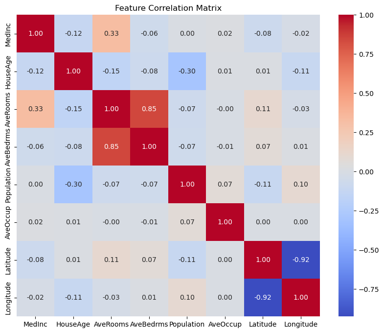

```python
corr = df[X.columns].corr()
plt.figure(figsize=(10, 8));
sns.heatmap(corr, annot=True, fmt=".2f", cmap="coolwarm");
plt.title("Feature Correlation Matrix");
plt.show();
```

```python
from termcolor import colored

# identify features with high VIF (e.g., > 5)
high_vif_features = vif_data[vif_data["VIF"] > 5]["Feature"].tolist()

drop_features = False
if drop_features:
    # Drop features with high VIF (e.g., > 5)
    X_train = X_train.drop(columns=high_vif_features)
    X_test = X_test.drop(columns=high_vif_features)

    # Notify the user with colored text
    if high_vif_features:
        print(colored(f"Dropped features due to high VIF (> 5): {', '.join(high_vif_features)}", 'red'))
    else:
        print(colored("No features were dropped due to high VIF.", 'green'))
```

#### 🔄 Independence of Residuals (optional)

**📖 Click to Expand**

- The **independence assumption** means that residuals should not be correlated with each other.
- This mainly applies to **time series** or **clustered data** — it's usually not a concern for cross-sectional datasets like California Housing.
- If applicable, test with:
  - **Durbin-Watson test** (values close to 2 indicate no autocorrelation)
  - **Plot residuals over observation index** to visually inspect patterns

```python
from statsmodels.stats.stattools import durbin_watson

# Run Durbin-Watson test on residuals
dw_stat = durbin_watson(residuals)
print(f"Durbin-Watson statistic: {dw_stat:.3f}")

# Simple interpretation for business context
if 1.5 <= dw_stat <= 2.5:
    print("✅ Residuals appear to be independent — no patterns over observations.")
else:
    print("⚠️ Residuals may not be independent — investigate possible autocorrelation.")

# Rule of thumb:
# ~2.0  → No autocorrelation
# <1.5 or >2.5 → Possible autocorrelation
```

```
Durbin-Watson statistic: 1.963
✅ Residuals appear to be independent — no patterns over observations.
```

#### 🛠️ Feature Engineering

**📖 Click to Expand**

- **Why engineer features?**
- Raw features may not capture real-world relationships well.
- Ratios, interactions, or log transforms can reveal hidden patterns.
- Good feature engineering often matters more than model choice.
- *Ommitted Here*

**📖 Click to Expand - Scaling**

- **Why scale features?**
- Many models (like regression, SVM, KNN) assume features are on similar scales.
- Scaling avoids one large-valued feature dominating others.
- It's essential for gradient-based optimization and distance-based models.

```python
# from sklearn.preprocessing import StandardScaler

# Initialize the scaler
# scaler = StandardScaler()

# Fit on training data and transform
# X_scaled = scaler.fit_transform(X)

# If you want a DataFrame back:
# X_scaled = pd.DataFrame(X_scaled, columns=X.columns, index=X.index)
```

```python
# Example: create ratio or interaction features
# df["RoomsPerPerson"] = df["AveRooms"] / (df["Population"] + 1)
# df["BedToRoomRatio"] = df["AveBedrms"] / (df["AveRooms"] + 1)

# Always inspect new features:
# df[["RoomsPerPerson", "BedToRoomRatio"]].describe()
```

#### 🧹 Preprocessing

```python
#### ✂️ Train-Test Split
from sklearn.model_selection import train_test_split

# Define features and target
X = df.drop(columns=[target_col])
y = df[target_col]

# Split into training and test sets
X_train, X_test, y_train, y_test = train_test_split(X, y, test_size=0.2, random_state=42)
```

```python
print("X_train: \n", X_train)
print("X_test: \n", X_test)
print("y_train: \n", y_train)
print("y_test: \n", y_test)
```

```
X_train:
        MedInc  HouseAge  AveRooms  AveBedrms  Population  AveOccup  Latitude  \
14196  3.2596      33.0  5.017657   1.006421      2300.0  3.691814     32.71
8267   3.8125      49.0  4.473545   1.041005      1314.0  1.738095     33.77
17445  4.1563       4.0  5.645833   0.985119       915.0  2.723214     34.66
14265  1.9425      36.0  4.002817   1.033803      1418.0  3.994366     32.69
2271   3.5542      43.0  6.268421   1.134211       874.0  2.300000     36.78
...       ...       ...       ...        ...         ...       ...       ...
11284  6.3700      35.0  6.129032   0.926267       658.0  3.032258     33.78
11964  3.0500      33.0  6.868597   1.269488      1753.0  3.904232     34.02
5390   2.9344      36.0  3.986717   1.079696      1756.0  3.332068     34.03
860    5.7192      15.0  6.395349   1.067979      1777.0  3.178891     37.58
15795  2.5755      52.0  3.402576   1.058776      2619.0  2.108696     37.77

       Longitude
```

[output cut: 67 more lines]

Back to the top

# 🧪 Baseline Model

**📖 Click to Expand**

🧠 **Why Track `best_model_info`?**

- In real-world pipelines, it's critical to:
- Compare models not just by accuracy, but a full suite of metrics.
- Store the actual model object, hyperparameters, and diagnostics in one place.
- Ensure only the **best-performing** model (based on chosen metrics) is promoted forward.

```python
import numpy as np

# Initialize Central tracker dictionary to track best model details upon iterations
best_model_info = {
    "name": None,
    "model": None,
    "metrics": {
        "train": {
            "r2": -np.inf,  # R² (higher is better)
            "adjusted_r2": -np.inf,  # Adjusted R² (higher is better)
            "mape": np.inf,  # Mean Absolute Percentage Error (lower is better)
            "rmse": np.inf,  # Root Mean Squared Error (lower is better)
            "mse": np.inf,  # Mean Squared Error (lower is better)
            "mae": np.inf,  # Mean Absolute Error (lower is better)
        },
        "test": {
            "r2": -np.inf,
            "adjusted_r2": -np.inf,
            "mape": np.inf,
            "rmse": np.inf,
            "mse": np.inf,
            "mae": np.inf,
        }
    },
    "hyperparameters": None
}

# Dictionary to store all model performance results for comparison
model_results = {}
```

**📖 Click to Expand - Success Metric**

**Metric to decide which model is "best"**

| Metric | Description | When to Use | Example |
| --- | --- | --- | --- |
| **r2** | R² score (higher is better, reflects model fit) | Understand how well the model explains the variance in the target variable | Predicting house prices where you want to know how well the features explain the price variance |
| **adjusted_r2** | Adjusted R² (corrects R² for number of predictors in model) | Compare models while accounting for model complexity | Real estate pricing models with multiple features (e.g., square footage, neighborhood) |
| **mape** | Mean Absolute Percentage Error (lower is better, interpretable as % error) | When % error is meaningful and easy to communicate | Forecasting sales where a 5% error matters for decision-making |
| **rmse** | Root Mean Squared Error (lower is better, penalizes large errors) | When large errors are especially costly and need stronger penalty | Energy consumption forecasting where spikes matter more than small fluctuations |
| **mse** | Mean Squared Error (lower is better, penalizes large errors) | Focus on reducing all squared errors, though less interpretable | Stock price prediction where minimizing overall error magnitude is critical |
| **mae** | Mean Absolute Error (lower is better, interpretable in original units) | When you want error in same units as target and easy to explain | Predicting monthly household spending (e.g., error in dollars) |

```python
# Success metric used to select the best model
success_metric = "r2"  # or "rmse", depending on your goals
# success_split = "test"  # "train" or "test"
```

```python
from sklearn.dummy import DummyRegressor

# Fit a dummy regressor as a baseline (predicting the mean)
dummy_regressor = DummyRegressor(strategy="mean")  # You can also try "median"
dummy_regressor.fit(X_train, y_train)
```

```
DummyRegressor()
```

```python
# Predict on both train and test
y_train_pred = dummy_regressor.predict(X_train)
y_test_pred = dummy_regressor.predict(X_test)

residuals_test = y_test - y_test_pred
residuals_train = y_train - y_train_pred
```

#### 🆚 Predicted vs Actual

```python
import matplotlib.pyplot as plt
import seaborn as sns

def plot_predicted_vs_actual(y_true, y_pred, title="Predicted vs Actual", data_type="Test Data"):
    """
    Plots the predicted values vs the actual values.

    Parameters:
    y_true : array-like
        Actual target values.
    y_pred : array-like
        Predicted target values.
    title : str
        Title of the plot (default is "Predicted vs Actual").
    data_type : str
        Label for the dataset type (default is "Test Data").
    """
    plt.figure(figsize=(8, 6))

    # Scatter plot for actual vs predicted values
    sns.scatterplot(x=y_true, y=y_pred, alpha=0.6, label=f"{data_type} Predictions")

    # Plot labels and title
    plt.xlabel("Actual Values", fontsize=12)
    plt.ylabel("Predicted Values", fontsize=12)
    plt.title(title, fontsize=14)

    # Add a legend
    plt.legend(loc="upper left", fontsize=10)

    # Add gridlines for better visualization
    plt.grid(True)

    # Tight layout
    plt.tight_layout()

    # Show the plot
    plt.show()
```

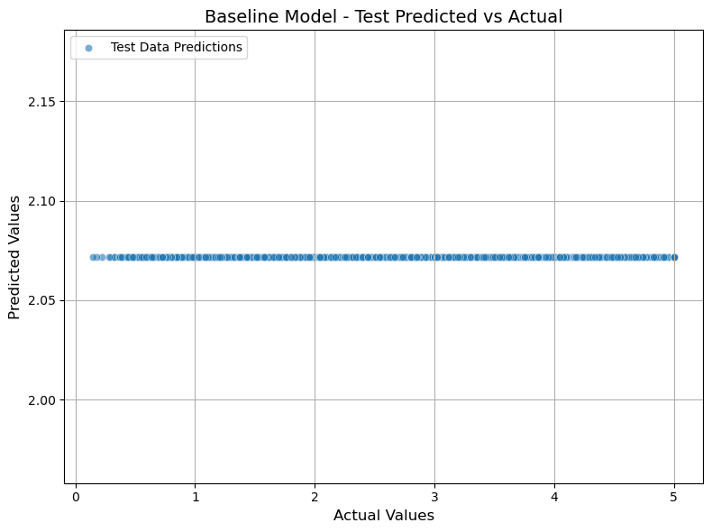

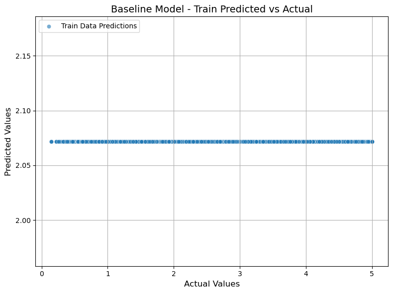

```python
plot_predicted_vs_actual(y_test, y_test_pred, title="Baseline Model - Test Predicted vs Actual", data_type="Test Data")
plot_predicted_vs_actual(y_train, y_train_pred, title="Baseline Model - Train Predicted vs Actual", data_type="Train Data")
```

#### 🌀 Residual Plot

And 📈 QQ Plot

```python
import matplotlib.pyplot as plt
import seaborn as sns
import scipy.stats as stats

def plot_residuals_vs_predicted(y_true, y_pred, label="Data", plot_qq=True):
    """
    Plots residuals vs predicted values and optionally a Q-Q plot of residuals.

    Parameters:
    y_true : array-like
        Actual target values.
    y_pred : array-like
        Predicted target values.
    label : str
        Label for the plot (e.g., "Train Data", "Test Data").
    plot_qq : bool
        Whether to plot the Q-Q plot of residuals (default is True).
    """
    # Calculate residuals
    residuals = y_true - y_pred

    # Plot: Residuals vs Predicted
    plt.figure(figsize=(8, 5))
    sns.scatterplot(x=y_pred, y=residuals, alpha=0.6)
    plt.axhline(0, linestyle='--', color='red')
    plt.xlabel("Predicted Values")
    plt.ylabel("Residuals")
    plt.title(f"Residuals vs Predicted - {label} (Homoscedasticity Check)")
    plt.tight_layout()
    plt.show()

    # Optionally, Q-Q plot of residuals
    if plot_qq:
        plt.figure(figsize=(6, 6))
        stats.probplot(residuals, dist="norm", plot=plt)
        plt.title(f"Q-Q Plot of Residuals - {label}")
        plt.tight_layout()
        plt.show()
```

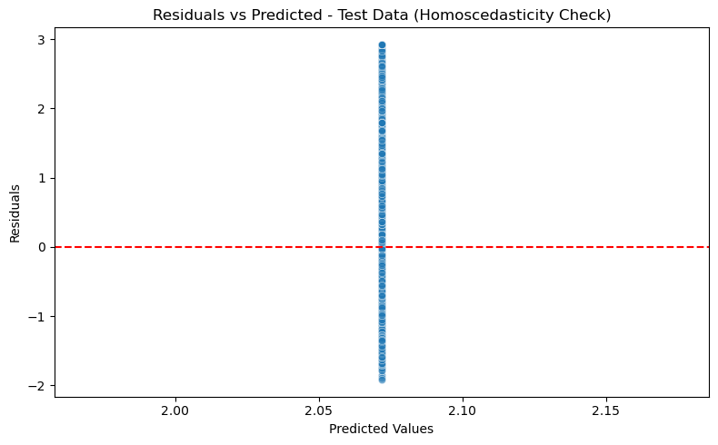

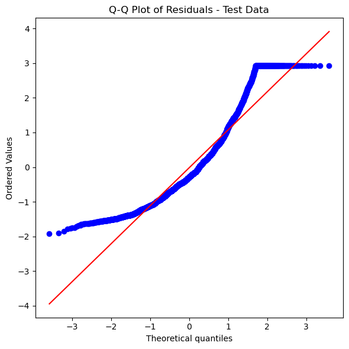

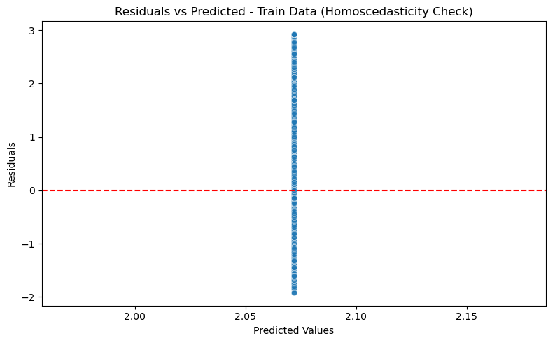

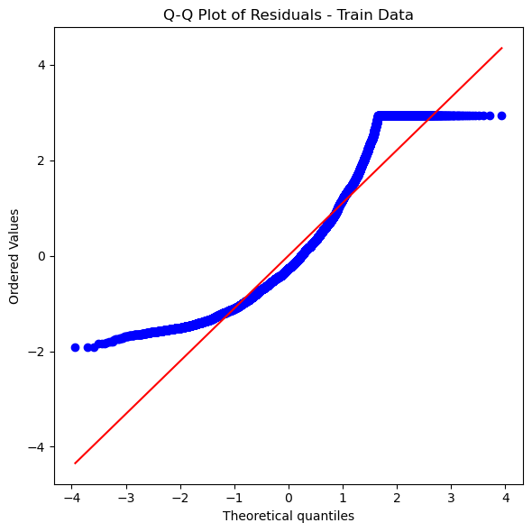

```python
plot_residuals_vs_predicted(y_test, y_test_pred, label="Test Data", plot_qq=True)
plot_residuals_vs_predicted(y_train, y_train_pred, label="Train Data", plot_qq=True)
```

#### 📏 Evaluation Metrics

**📖 Click to Expand**

- **R² (R-squared)**: Measures how well the model explains the variance in the target variable. A higher R² indicates better model fit. A value of 1 indicates perfect fit, while 0 indicates the model doesn't explain any variance.
- **Adjusted R²**: Similar to R² but adjusts for the number of predictors in the model. Useful when comparing models with different numbers of features.
- **Mean Absolute Error (MAE)**: The average of the absolute differences between predicted and actual values. It provides a straightforward interpretation of model performance in the same units as the target variable.
- **Mean Squared Error (MSE)**: The average of the squared differences between predicted and actual values. MSE penalizes larger errors more than MAE.
- **Root Mean Squared Error (RMSE)**: The square root of MSE. It provides a more interpretable value by returning the error in the same units as the target variable, while still penalizing large errors.
- **Mean Absolute Percentage Error (MAPE)**: Expresses the error as a percentage, making it easier to understand in business terms. A lower MAPE indicates better model accuracy.

**MAE, MSE, and RMSE** are the primary regression metrics:

- **MAE**: Easier to interpret in the same units as the target variable. It’s useful when you want a simple error metric.
- **MSE**: Penalizes larger errors more heavily than MAE. Useful when large errors are especially undesirable.
- **RMSE**: More interpretable than MSE, since it’s in the same units as the target variable. It’s widely used when you want to penalize large errors more.

**Business Perspective:**

- **MAPE** is often preferred when you need an easily interpretable error metric in percentage terms, especially for business use cases like sales forecasting or demand prediction.
- **MAE** is useful when you care about errors in the **same unit** as your target, and when you don’t want to penalize large errors disproportionately.
- **RMSE** is important when large errors have a significant impact on the business and you want to **penalize** them more heavily than smaller ones.
- **R²** is key when you want to understand **how well the model fits** the data, but may not always be reliable in the presence of outliers or non-linear relationships.

These metrics provide a more comprehensive understanding of model performance, especially when accuracy alone is not sufficient in regression tasks.

```python
from sklearn.metrics import mean_squared_error, mean_absolute_error, r2_score
import numpy as np

def evaluate_model_performance(
    X_train, y_train, y_train_pred, X_test, y_test, y_test_pred, label="Model"
):
    """
    Evaluate model performance for both training and testing data, including core metrics and business interpretation.
    """
    # --- Train Performance ---
    print(f"\n🔧 {label} - Train Performance")

    # Ensure shapes match for multi-output models
    if len(y_train.shape) == 2 and len(y_train_pred.shape) == 2:  # Multi-output
        r2_train = [r2_score(y_train[:, i], y_train_pred[:, i]) for i in range(y_train.shape[1])]
    else:  # Single output
        r2_train = r2_score(y_train, y_train_pred)

    adjusted_r2_train = 1 - (1 - r2_train) * (len(y_train) - 1) / (len(y_train) - X_train.shape[1] - 1)
    mae_train = mean_absolute_error(y_train, y_train_pred)
    rmse_train = np.sqrt(mean_squared_error(y_train, y_train_pred))
    mape_train = np.mean(np.abs((y_train - y_train_pred) / y_train)) * 100
    mse_train = mean_squared_error(y_train, y_train_pred)

    print(f"R²: {r2_train:.3f} → Explains {r2_train*100:.0f}% of variation in target")
    print(f"Adjusted R²: {adjusted_r2_train:.3f}")
    print(f"MAPE: {mape_train:.2f}% → On average, we're off by this percentage")
    print(f"MAE: {mae_train:.2f} → On average, we're off by ±${mae_train*100000:.0f}")
    print(f"RMSE: {rmse_train:.2f} → Penalizes big misses more heavily")
    print(f"MSE: {mse_train:.2f} → Mean squared error")

    # --- Test Performance ---
    print(f"\n🧪 {label} - Test Performance")

    if len(y_test.shape) == 2 and len(y_test_pred.shape) == 2:  # Multi-output
        r2_test = [r2_score(y_test[:, i], y_test_pred[:, i]) for i in range(y_test.shape[1])]
    else:  # Single output
        r2_test = r2_score(y_test, y_test_pred)

    adjusted_r2_test = 1 - (1 - r2_test) * (len(y_test) - 1) / (len(y_test) - X_test.shape[1] - 1)
    mae_test = mean_absolute_error(y_test, y_test_pred)
    rmse_test = np.sqrt(mean_squared_error(y_test, y_test_pred))
    mape_test = np.mean(np.abs((y_test - y_test_pred) / y_test)) * 100
    mse_test = mean_squared_error(y_test, y_test_pred)

    print(f"R²: {r2_test:.3f} → Explains {r2_test*100:.0f}% of variation in target")
    print(f"Adjusted R²: {adjusted_r2_test:.3f}")
    print(f"MAPE: {mape_test:.2f}% → On average, we're off by this percentage")
    print(f"MAE: {mae_test:.2f} → On average, we're off by ±${mae_test*100000:.0f}")
    print(f"RMSE: {rmse_test:.2f} → Penalizes big misses more heavily")
    print(f"MSE: {mse_test:.2f} → Mean squared error")

    # --- Business Interpretation ---
    print("\n📌 Interpretation:")
    if mape_test > 10:
        print("- High MAPE → model might need improvement.")
    else:
        print("- MAPE is acceptable; model is performing well.")

    if mae_test > 1:
        print("- High MAE → model might need improvement.")
    else:
        print("- MAE is acceptable; the model is performing well.")

    if rmse_test > 1:
        print("- High RMSE → model is not handling large errors well.")
    else:
        print("- RMSE is acceptable; model is not penalizing large errors excessively.")

    print(f"- R² indicates model fit: {r2_test:.2f}")
    print(f"- Adjusted R² accounts for complexity: {adjusted_r2_test:.2f}")
```

```python
evaluate_model_performance(
    X_train, y_train, y_train_pred, X_test, y_test, y_test_pred, label="Baseline_Model"
)
```

```
🔧 Baseline_Model - Train Performance
R²: 0.000 → Explains 0% of variation in target
Adjusted R²: -0.000
MAPE: 62.08% → On average, we're off by this percentage
MAE: 0.91 → On average, we're off by ±$91391
RMSE: 1.16 → Penalizes big misses more heavily
MSE: 1.34 → Mean squared error

🧪 Baseline_Model - Test Performance
R²: -0.000 → Explains -0% of variation in target
Adjusted R²: -0.002
MAPE: 62.89% → On average, we're off by this percentage
MAE: 0.91 → On average, we're off by ±$90607
RMSE: 1.14 → Penalizes big misses more heavily
MSE: 1.31 → Mean squared error

📌 Interpretation:
- High MAPE → model might need improvement.
- MAE is acceptable; the model is performing well.
- High RMSE → model is not handling large errors well.
- R² indicates model fit: -0.00
- Adjusted R² accounts for complexity: -0.00
```

#### 🧮 Update Best Model Info

```python
import numpy as np
from termcolor import colored
from sklearn.metrics import mean_absolute_error, mean_squared_error, r2_score

def update_best_model_info(model_name, model_obj, y_train, y_test, y_train_pred, y_test_pred, hyperparameters=None, mask=False):
    """
    Computes prediction metrics internally, updates best_model_info if model outperforms current best.
    Also logs all model results.
    """
    # Evaluate performance
    metrics = {
        "train": {
            "r2": r2_score(y_train, y_train_pred),
            "adjusted_r2": 1 - (1 - r2_score(y_train, y_train_pred)) * (len(y_train) - 1) / (len(y_train) - X_train.shape[1] - 1),
            "mape": np.mean(np.abs((y_train - y_train_pred) / y_train)) * 100,
            "rmse": np.sqrt(mean_squared_error(y_train, y_train_pred)),
            "mse": mean_squared_error(y_train, y_train_pred),
            "mae": mean_absolute_error(y_train, y_train_pred)
        },
        "test": {
            "r2": r2_score(y_test, y_test_pred),
            "adjusted_r2": 1 - (1 - r2_score(y_test, y_test_pred)) * (len(y_test) - 1) / (len(y_test) - X_test.shape[1] - 1),
            "mape": np.mean(np.abs((y_test - y_test_pred) / y_test)) * 100,
            "rmse": np.sqrt(mean_squared_error(y_test, y_test_pred)),
            "mse": mean_squared_error(y_test, y_test_pred),
            "mae": mean_absolute_error(y_test, y_test_pred)
        }
    }

    # Compare with current best
    current_score = metrics["test"][success_metric]
    best_score = best_model_info["metrics"]["test"].get(success_metric, -np.inf)
    previous_best = best_model_info["name"] or "None"

    if current_score > best_score:
        if not mask:
            best_model_info.update({
                "name": model_name,
                "model": model_obj,
                "metrics": metrics,
                "hyperparameters": hyperparameters or {}
            })
        print(colored(
            f"✅ {model_name} just beat previous best ({previous_best}) → "
            f"{success_metric}: {best_score:.4f} → {current_score:.4f}", "green"))
    else:
        print(f"⚠️ {model_name} did not improve the best score.")

    # Log all model results
    model_results[model_name] = {
        "model": model_obj,
        "metrics": metrics,
        "hyperparameters": hyperparameters or {}
    }
```

```python
# Example usage with the existing Dummy Regressor (Baseline Model)
update_best_model_info(
    model_name="Baseline Model",
    model_obj=dummy_regressor,  # Using the existing baseline model
    y_train=y_train,
    y_test=y_test,
    y_train_pred=y_train_pred,
    y_test_pred=y_test_pred,
    hyperparameters={"strategy": "mean"}
)
```

```
✅ Baseline Model just beat previous best (None) → r2: -inf → -0.0002
```

```python
# from pprint import pprint
# pprint(best_model_info)
# pprint(model_results)

# import json
# print(json.dumps(best_model_info, indent=2, default=str))
# print(json.dumps(model_results, indent=2, default=str))
```

Back to the top

# 🔍 Algorithms

**📖 Click to Expand - Suitability Checklist (All Models)**

| Criterion | ⚙️ Linear Regression | 🧊 Ridge Regression | 🔥 Lasso Regression | 🧃 ElasticNet | 🌳 Decision Trees | 🪵 Random Forests | 🚀 Gradient Boosting (XGBoost, LightGBM) | ⚙️ Support Vector Machines (SVR) | 🧠 K-Nearest Neighbors (KNN) |
| --- | --- | --- | --- | --- | --- | --- | --- | --- | --- |
| **Interpretability** | ✅ Excellent – coefficients are directly interpretable | ⚠️ Moderate – coefficients interpretable, but shrunk due to L2 penalty | ⚠️ Moderate – less interpretable due to variable shrinkage, but aids feature selection | ⚠️ Moderate – coefficients are shrunk and partially zeroed; harder to interpret | ✅ Good – tree structure is easy to visualize and explain | ❌ Low – individual trees are interpretable, but the ensemble is not | ❌ Low – ensembles are complex; interpretability requires SHAP or similar tools | ❌ Low – lacks clear coefficients or rule-based structure | ⚠️ Moderate – intuitive to explain, but no learned model or coefficients |
| **Linearity Expectation** | ✅ Yes – assumes a linear relationship between features and target | ✅ Yes – assumes linear relationship between features and target | ✅ Yes – assumes linear relationship between features and target | ✅ Yes – assumes linear relationship between features and target | ✅ No – captures complex non-linear relationships naturally | ✅ No – models complex non-linear relationships naturally | ✅ No – captures highly non-linear relationships | ⚠️ Depends – linear SVR assumes linearity; kernel SVR handles non-linear patterns | ✅ No – models non-linear patterns based on local neighborhoods |
| **High dimensionality** | ⚠️ Moderate – can overfit without regularization (use Ridge/Lasso) | ✅ Good – handles many features with L2 regularization | ✅ Very good – performs implicit feature selection via L1 penalty | ✅ Excellent – handles many features well, especially when correlated | ⚠️ Moderate – prone to overfitting with many features unless pruned | ✅ Good – handles many features well via random feature selection | ✅ Excellent – handles large feature sets with built-in feature importance and regularization | ✅ Very good – effective in high-dimensional spaces, especially with appropriate kernels | ❌ Poor – suffers from the curse of dimensionality; distance metrics lose meaning |
| **Handling of multicollinearity** | ❌ Poor – highly sensitive unless regularized | ✅ Good – L2 penalty reduces impact of correlated features | ⚠️ Partial – tends to pick one feature among correlated ones | ✅ Better than Lasso – distributes weight across correlated features | ✅ Handles – splits on strongest feature; ignores others | ✅ Handles – less sensitive due to randomized feature selection in each tree | ✅ Robust – tends to pick one feature among correlated ones; not harmed significantly | ⚠️ Somewhat handles – regularization helps, but not designed to resolve multicollinearity explicitly | ❌ Problematic – redundant features distort distance-based similarity |
| **Handling of categorical features** | ❌ Not supported natively – requires one-hot or ordinal encoding | ❌ Requires encoding – use one-hot or ordinal encoding | ❌ Requires encoding – one-hot or ordinal encoding needed | ❌ Requires encoding – one-hot or ordinal encoding needed | ⚠️ Requires encoding – label encoding preferred; not ideal with high-cardinality | ⚠️ Requires encoding – typically label encoding; not optimal with high-cardinality | ⚠️ Requires encoding – label encoding usually sufficient; LightGBM supports native categorical handling | ❌ Not supported natively – requires proper encoding and kernel compatibility | ❌ Not natively supported – requires encoding and careful distance handling |
| **Handling of outliers** | ❌ Sensitive – predictions and coefficients can be skewed | ❌ Sensitive – does not explicitly handle outliers | ❌ Sensitive – does not explicitly handle outliers | ❌ Sensitive – still affected by extreme values | ✅ Robust – splits based on thresholds, not influenced by extreme values | ✅ Robust – ensemble effect reduces outlier influence | ✅ Robust – tree splits reduce outlier influence significantly | ❌ Sensitive – margin-based loss can be distorted by outliers | ❌ Sensitive – local predictions easily skewed by nearby outliers |
| **Handling of missing values** | ❌ Not supported – needs imputation before modeling | ❌ Not supported – requires imputation | ❌ Not supported – requires imputation | ❌ Not supported – requires imputation | ⚠️ Partial – some implementations handle them natively, others require imputation | ⚠️ Partial – some implementations support it; others need imputation | ✅ Supported – both XGBoost and LightGBM handle missing values natively during tree construction | ❌ Not supported – must impute missing data beforehand | ❌ Not supported – requires complete cases or imputation beforehand |
| **Scaling of features needed** | ⚠️ Sometimes – needed with regularization or interaction terms | ✅ Yes – regularization depends on feature magnitude | ✅ Yes – essential due to L1 penalty sensitivity | ✅ Yes – critical due to combined penalties | ✅ Not needed – trees are scale-invariant | ✅ Not needed – tree-based and scale-invariant | ✅ Not needed – models are scale-invariant | ✅ Yes – essential for stable and effective optimization (especially with RBF kernel) | ✅ Yes – crucial, since all predictions are based on distance |
| **Handling of sparseness in data** | ⚠️ Limited – better with regularization and preprocessing | ⚠️ Moderate – doesn't zero out coefficients, better with dense data | ✅ Good – promotes sparsity in coefficients, useful for sparse signals | ✅ Good – promotes sparsity but more stable than Lasso alone | ⚠️ Limited – not ideal for very sparse matrices like bag-of-words | ⚠️ Moderate – performs okay, but not best for highly sparse data | ✅ Excellent – built-in support for sparse data (e.g., in XGBoost and LightGBM) | ✅ Good – works well in sparse high-dimensional cases (e.g., text with linear kernel) | ❌ Poor – sparse vectors make nearest neighbor distances unreliable |
| **Skewed target distribution** | ⚠️ Assumes homoscedasticity – may underperform on skewed targets | ⚠️ Assumes homoscedasticity – performance may drop on skewed targets | ⚠️ Assumes homoscedasticity – not ideal for highly skewed targets | ⚠️ Assumes homoscedasticity – not ideal for skewed distributions | ✅ Handles well – no distributional assumptions | ✅ Handles – no assumption about target distribution | ✅ Handles well – flexible enough to model skewed targets without assumptions | ⚠️ Handles better than OLS, but predictions are bounded by ε-margin; tuning required | ⚠️ Affected – highly skewed targets can lead to biased local averages |
| **Assumes normality of residuals?** | ✅ Yes – important for inference and prediction intervals | ✅ Yes – for valid inference and confidence intervals | ✅ Yes – for statistical inference, if needed post-selection | ✅ Yes – standard inference assumptions apply post-selection | ❌ No – non-parametric, no residual distribution assumption | ❌ No – fully non-parametric model | ❌ No – fully non-parametric, no assumptions on residual distribution | ❌ No – non-parametric and does not rely on residual distribution assumptions | ❌ No – non-parametric, no assumptions on residuals or distributions |
| **Accuracy** | ✅ Strong when assumptions hold; good as a baseline | ✅ Often better than linear regression when multicollinearity is present | ✅ Strong when only a subset of features are useful; acts as model + selector | ✅ Flexible – performs well when features are correlated and some sparsity is expected | ⚠️ Can overfit – strong on small to medium data, weaker alone on complex patterns | ✅ Strong – often top-tier performance on structured/tabular data | ✅ Top-tier – often best-in-class for structured/tabular regression problems | ✅ High – strong performance with well-tuned kernel and hyperparameters | ⚠️ Variable – performs well with clean, low-dimensional, dense data; poor elsewhere |
| **Training speed** | ✅ Very fast – efficient even on large datasets | ✅ Fast – nearly as efficient as linear regression | ✅ Fast for small to medium datasets; slower with very high dimensionality | ⚠️ Slower than Ridge/Lasso – due to tuning two hyperparameters (`alpha`, `l1_ratio`) | ✅ Fast – efficient even on large datasets with moderate depth | ⚠️ Slower than single models – but parallelizable and scalable | ⚠️ Slower than simpler models – but optimized and scalable (especially with LightGBM and GPU support) | ❌ Slow – especially with large datasets or non-linear kernels | ✅ Fast training (lazy learner), ❌ Slow inference – computes distances at prediction time |

### ⚙️ Algorithms - Linear Regression

**📖 Click to Expand**

A **linear regression model** estimates the outcome as a weighted sum of input features:

**Equation:**  
$\hat{y} = \beta_0 + \beta_1 x_1 + \beta_2 x_2 + \dots + \beta_n x_n$

**Where:**

- **$\hat{y}$**: Predicted value
- **$\beta_0$**: Intercept
- **$x_i$**: Input feature
- **$\beta_i$**: Weight of each feature

The model finds the best-fitting line by minimizing the **sum of squared errors**:

**Objective:**  
$\text{Minimize} \quad \sum (y_i - \hat{y}_i)^2$

In business terms:  
Each feature has a consistent “price tag” — the model tells you how much a change in input pushes the prediction up or down.

**📖 Click to Expand - Suitability Checklist**

| Criterion | Comment |
| --- | --- |
| **Interpretability** | ✅ Excellent – coefficients are directly interpretable |
| **Linearity Expectation** | ✅ Yes – assumes a linear relationship between features and target |
| **High dimensionality** | ⚠️ Moderate – can overfit without regularization (use Ridge/Lasso) |
| **Handling of multicollinearity** | ❌ Poor – highly sensitive unless regularized |
| **Handling of categorical features** | ❌ Not supported natively – requires one-hot or ordinal encoding |
| **Handling of outliers** | ❌ Sensitive – predictions and coefficients can be skewed |
| **Handling of missing values** | ❌ Not supported – needs imputation before modeling |
| **Scaling of features needed** | ⚠️ Sometimes – needed with regularization or interaction terms |
| **Handling of sparseness in data** | ⚠️ Limited – better with regularization and preprocessing |
| **Skewed target distribution** | ⚠️ Assumes homoscedasticity – may underperform on skewed targets |
| **Assumes normality of residuals?** | ✅ Yes – important for inference and prediction intervals |

- **General comment on accuracy**: ✅ Strong when assumptions hold; good as a baseline
- **General comment on training speed**: ✅ Very fast – efficient even on large datasets

#### 🏗️ Model Fit

```python
from sklearn.linear_model import LinearRegression
from sklearn.model_selection import train_test_split

# Recreate X and y if needed
X = df.drop(columns=[target_col])
y = df[target_col]

# Split the data
X_train, X_test, y_train, y_test = train_test_split(X, y, random_state=42)

# Fit base linear regression model
lr = LinearRegression()
lr.fit(X_train, y_train)

# Predict
y_train_pred = lr.predict(X_train)
y_test_pred = lr.predict(X_test)
```

```
LinearRegression()
```

#### 🔍 Leverage - Outlier Detection

**📖 Click to Expand - Leverage**

##### 🧠 What is Leverage?

- **Leverage** measures how far an observation's feature values are from the mean of all observations.
- It identifies points that sit on the edge of the predictor space — even if they don’t have large residuals.
- In matrix terms, leverage comes from the **hat matrix** $H = X(X^TX)^{-1}X^T$.

##### 📐 Math:

- The **leverage score** for point $i$ is $h_i = H_{ii}$ (the diagonal of the hat matrix).
- $h_i$ ranges from $0$ to $1$, and high values mean the observation has strong influence on its own predicted value.

##### 💡 Intuition:

- High leverage points may not be outliers in $y$, but they have unusual $X$ values.
- Think of them as **data points in weird neighborhoods** — the model leans heavily on them to make predictions there.

**📖 Click to Expand - What if high leverage?**

##### 🚨 What It Means

- High leverage points have **unusual input values** — they sit far from the average data pattern.
- The model relies heavily on them to define the shape of the regression line.
- They're not necessarily outliers in the target, but they’re structurally extreme.

##### 🧠 What You Can Do

- **Inspect**: Are they legit or data glitches?
- **Compare**: Refit the model without them — if results shift a lot, they're too influential.
- **Mitigate**: Use robust models (Ridge, Trees), cap feature extremes, or reweight carefully.

##### 💡 Key Insight

> High leverage = “this point is setting the rules.” Sometimes that’s okay. Sometimes it’s dangerous.

```
<StemContainer object of 3 artists>
```

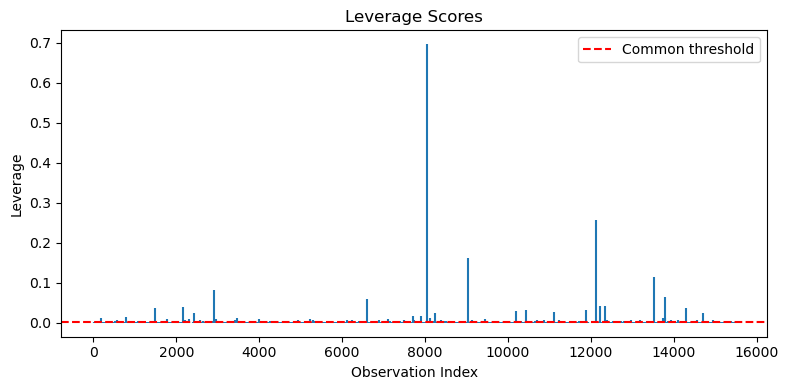

```python
import numpy as np
import statsmodels.api as sm
import matplotlib.pyplot as plt

# Add intercept to X for statsmodels
X_with_const = sm.add_constant(X_train)

# Fit OLS model using statsmodels
model = sm.OLS(y_train, X_with_const).fit()

# Get leverage scores from hat matrix
influence = model.get_influence()
leverage = influence.hat_matrix_diag

# Plot leverage scores
plt.figure(figsize=(8, 4));
plt.stem(np.arange(len(leverage)), leverage, markerfmt=" ", basefmt=" ");
plt.axhline(2 * X_with_const.shape[1] / X_with_const.shape[0], color='red', linestyle='--', label='Common threshold');
plt.xlabel("Observation Index");
plt.ylabel("Leverage");
plt.title("Leverage Scores");
plt.legend();
plt.tight_layout();
plt.show();
```

```python
# Show top N leverage observations with full feature + target + leverage score
top_n = 5
top_idx = np.argsort(leverage)[-top_n:][::-1]

# Build DataFrame
high_leverage_df = X_train.iloc[top_idx].copy()
high_leverage_df[y_train.name] = y_train.iloc[top_idx].values
high_leverage_df["Leverage"] = leverage[top_idx]

print(f"🔍 Top {top_n} High-Leverage Observations:")
display(high_leverage_df)
```

```
🔍 Top 5 High-Leverage Observations:
```

|  | MedInc | HouseAge | AveRooms | AveBedrms | Population | AveOccup | Latitude | Longitude | MedHouseVal | Leverage |
| --- | --- | --- | --- | --- | --- | --- | --- | --- | --- | --- |
| 19006 | 10.2264 | 45.0 | 3.166667 | 0.833333 | 7460.0 | 1243.333333 | 38.32 | -121.98 | 1.37500 | 0.696212 |
| 1914 | 1.8750 | 33.0 | 141.909091 | 25.636364 | 30.0 | 2.727273 | 38.91 | -120.10 | 5.00001 | 0.255724 |
| 3364 | 5.5179 | 36.0 | 5.142857 | 1.142857 | 4198.0 | 599.714286 | 40.41 | -120.51 | 0.67500 | 0.162325 |
| 16669 | 4.2639 | 46.0 | 9.076923 | 1.307692 | 6532.0 | 502.461538 | 35.32 | -120.70 | 3.50000 | 0.115033 |
| 11862 | 2.6250 | 25.0 | 59.875000 | 15.312500 | 28.0 | 1.750000 | 40.27 | -121.25 | 0.67500 | 0.082439 |

#### 🔥 Cook’s Distance - Outlier Detection

**📖 Click to Expand**

##### 🔥 What It Measures

- **Cook’s Distance** combines both **leverage** and **residual size**.
- It tells you how much the model's predictions would **change** if you removed a specific observation.
- In short: **“How much does this point bend the model?”**

##### 📐 Math (Simplified)

For each point $i$:

$D_i = \frac{(y_i - \hat{y}_i)^2}{p \cdot MSE} \cdot \frac{h_i}{(1 - h_i)^2}$

where:

- $h_i$ = leverage
- $p$ = number of parameters
- $MSE$ = mean squared error

##### 🧠 What To Do With It

- Points with **high Cook’s D** have both high leverage *and* large residuals → red flags.
- They may be real edge cases or data issues — investigate.
- Use a threshold like `4 / n` or compare to the top 5% of values.

##### 💡 Intuition

> Leverage = weird position.  
> Residual = big error.  
> **Cook’s Distance = both.**

```
<StemContainer object of 3 artists>
```

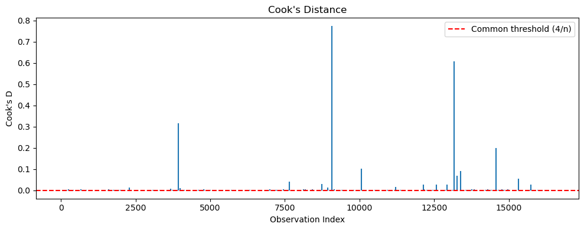

```
🔥 Top 5 Most Influential Observations (Cook’s Distance):
```

|  | MedInc | HouseAge | AveRooms | AveBedrms | Population | AveOccup | Latitude | Longitude | MedHouseVal | Cook's D |
| --- | --- | --- | --- | --- | --- | --- | --- | --- | --- | --- |
| 19006 | 10.2264 | 45.0 | 3.166667 | 0.833333 | 7460.0 | 1243.333333 | 38.32 | -121.98 | 1.37500 | 0.773982 |
| 1914 | 1.8750 | 33.0 | 141.909091 | 25.636364 | 30.0 | 2.727273 | 38.91 | -120.10 | 5.00001 | 0.607112 |
| 11862 | 2.6250 | 25.0 | 59.875000 | 15.312500 | 28.0 | 1.750000 | 40.27 | -121.25 | 0.67500 | 0.316914 |
| 16669 | 4.2639 | 46.0 | 9.076923 | 1.307692 | 6532.0 | 502.461538 | 35.32 | -120.70 | 3.50000 | 0.199847 |
| 3364 | 5.5179 | 36.0 | 5.142857 | 1.142857 | 4198.0 | 599.714286 | 40.41 | -120.51 | 0.67500 | 0.101675 |

```python
import statsmodels.api as sm
import matplotlib.pyplot as plt
import numpy as np
import pandas as pd

# Add constant and fit OLS model
X_with_const = sm.add_constant(X_train)
model = sm.OLS(y_train, X_with_const).fit()

# Compute influence
influence = model.get_influence()
cooks_d = influence.cooks_distance[0]  # First element is the array of distances

# Plot Cook's Distance
plt.figure(figsize=(10, 4));
plt.stem(np.arange(len(cooks_d)), cooks_d, markerfmt=" ", basefmt=" ");
plt.axhline(4 / len(X_train), color='red', linestyle='--', label="Common threshold (4/n)");
plt.title("Cook's Distance");
plt.xlabel("Observation Index");
plt.ylabel("Cook's D");
plt.legend();
plt.tight_layout();
plt.show();

# Print top N influential points
top_n = 5
top_idx = np.argsort(cooks_d)[-top_n:][::-1]
cooks_df = X_train.iloc[top_idx].copy()
cooks_df[y_train.name] = y_train.iloc[top_idx].values
cooks_df["Cook's D"] = cooks_d[top_idx]

print(f"🔥 Top {top_n} Most Influential Observations (Cook’s Distance):")
display(cooks_df)
```

#### 🔢 Coefficients

```python
# View model coefficients
coeff_df = pd.DataFrame({
    "Feature": X.columns,
    "Coefficient": lr.coef_
}).sort_values(by="Coefficient", key=abs, ascending=False)

# Identify most impactful positive and negative drivers
top_positive = coeff_df.iloc[0]
top_negative = coeff_df.iloc[coeff_df["Coefficient"].idxmin()]

print("🧠 Interpretation Summary:")
print(f"- 💡 '{top_positive['Feature']}' has the strongest positive effect on {target_col} (for a unit increase).")
print(f"- 🔻 '{top_negative['Feature']}' has the strongest negative effect on {target_col} (for a unit increase).")

# Optional threshold for low-impact features
low_impact = coeff_df[coeff_df["Coefficient"].abs() < 0.01]["Feature"].tolist()
if low_impact:
    print(f"- 💤 Features like {', '.join(low_impact)} have **minimal predictive power** in this model.")


coeff_df
```

[output not shown]

|  | Feature | Coefficient |
| --- | --- | --- |
| 3 | AveBedrms | 0.794471 |
| 0 | MedInc | 0.447600 |
| 7 | Longitude | -0.433405 |
| 6 | Latitude | -0.418555 |
| 2 | AveRooms | -0.124756 |
| 1 | HouseAge | 0.009568 |
| 5 | AveOccup | -0.003443 |
| 4 | Population | -0.000001 |

#### 🧮 VIF (optional)

**📖 Click to Expand**

##### 📐 What is VIF?

- **Variance Inflation Factor (VIF)** quantifies how much the **variance of a regression coefficient** is inflated due to **multicollinearity** among the independent variables.
- It helps detect **redundant features** in a linear regression model.

##### 🧮 Mathematical Formula

For a given feature ( X_j ):

Where:

- ( R_j^2 ) is the coefficient of determination obtained by regressing ( X_j ) on all the other predictors.

##### 🔍 Interpretation

| VIF Value | Meaning |
| --- | --- |
| 1 | No multicollinearity |
| 1 – 5 | Moderate multicollinearity (usually fine) |
| > 5 | Concerning – consider dropping or combining features |
| > 10 | Problematic – strong multicollinearity |

```python
import statsmodels.api as sm
from statsmodels.stats.outliers_influence import variance_inflation_factor

# Recompute VIF for final X
X_with_const = sm.add_constant(X)
vif_data = pd.DataFrame()
vif_data["Feature"] = X.columns
vif_data["VIF"] = [variance_inflation_factor(X_with_const.values, i + 1) for i in range(X.shape[1])]
vif_data = vif_data.sort_values("VIF", ascending=False)

# Show table
display(vif_data)

# Interpretation
vif_threshold = 5
high_vif = vif_data[vif_data["VIF"] > vif_threshold]["Feature"].tolist()

print("\n📉 Multicollinearity Interpretation:")
if high_vif:
    print(f"- ⚠️ The following features may be strongly correlated with others: {', '.join(high_vif)}")
    print("- This could make individual feature effects harder to trust.")
else:
    print("- ✅ No problematic multicollinearity — all features are within acceptable VIF range.")
```

|  | Feature | VIF |
| --- | --- | --- |
| 6 | Latitude | 9.297624 |
| 7 | Longitude | 8.962263 |
| 2 | AveRooms | 8.342786 |
| 3 | AveBedrms | 6.994995 |
| 0 | MedInc | 2.501295 |
| 1 | HouseAge | 1.241254 |
| 4 | Population | 1.138125 |
| 5 | AveOccup | 1.008324 |

```
📉 Multicollinearity Interpretation:
- ⚠️ The following features may be strongly correlated with others: Latitude, Longitude, AveRooms, AveBedrms
- This could make individual feature effects harder to trust.
```

#### 📊 What impacts R²

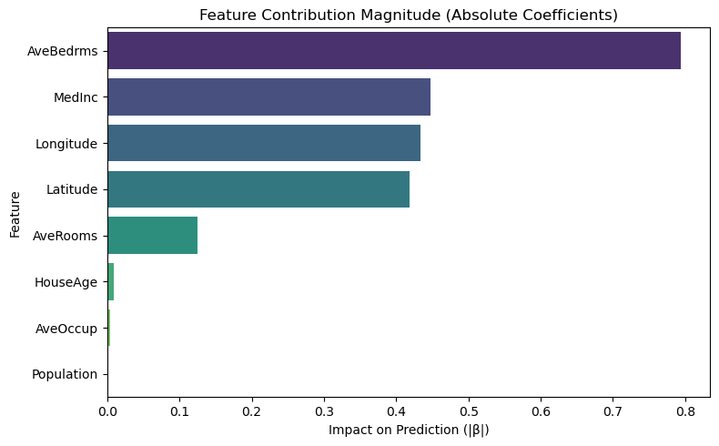

```
🧠 Interpretation:
- The higher the margitude, the more influence that feature has on the prediction — regardless of direction.
- This helps identify which features the model is leaning on most heavily to make predictions.
- Note: High influence doesn’t mean causation — just strong correlation within this dataset.
```

```python
# Bar plot of absolute coefficients to show feature impact on variance explained
plt.figure(figsize=(8, 5))
sns.barplot(
    x=coeff_df["Coefficient"].abs(),
    y=coeff_df["Feature"],
    palette="viridis"
)
plt.title("Feature Contribution Magnitude (Absolute Coefficients)")
plt.xlabel("Impact on Prediction (|β|)")
plt.ylabel("Feature")
plt.tight_layout()
plt.show()

# Business interpretation
print("🧠 Interpretation:")
print("- The higher the margitude, the more influence that feature has on the prediction — regardless of direction.")
print("- This helps identify which features the model is leaning on most heavily to make predictions.")
print("- Note: High influence doesn’t mean causation — just strong correlation within this dataset.")
```

#### 🚨 Overfitting indicators

```python
# Quick check: Train vs Test R²
print(f"Train R²: {r2_score(y_train, y_train_pred):.3f}")
print(f"Test  R²: {r2_score(y_test, y_test_pred):.3f}")

gap = r2_score(y_train, y_train_pred) - r2_score(y_test, y_test_pred)
print(f"Gap: {gap:.3f}")

if gap > 0.1:
    print("⚠️ Likely overfitting — model performs much better on training data.")
else:
    print("✅ No strong overfitting signal — train/test performance is similar.")
```

```
Train R²: 0.610
Test  R²: 0.591
Gap: 0.019
✅ No strong overfitting signal — train/test performance is similar.
```

#### 🔬 SHAP

**📖 Click to Expand**

- **SHAP (SHapley Additive exPlanations)** helps explain how much each feature contributed to a specific prediction.
- Unlike coefficients, SHAP accounts for interactions and context — making it more reliable for understanding **why** the model made a decision.
- Think of it like **splitting the credit** (or blame) for each prediction across features.
- **PDP (Partial Dependence Plots)** show how a single feature affects predictions while holding others constant.
- Useful to answer: *“As this feature increases, does the predicted outcome go up or down — and by how much?”*

Together, SHAP and PDP bridge the gap between complex models and human intuition.

```
LinearRegression()
```

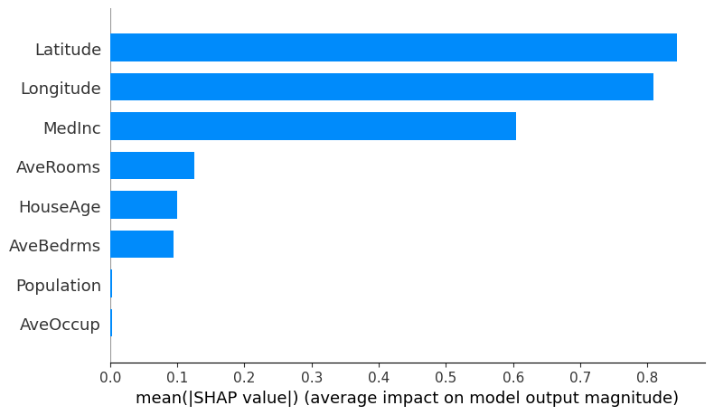

```
🧠 Interpretation:
- This shows which features contribute most to the model’s predictions across all data points.
- The top features are the biggest drivers of predicted changes in the target.
- Unlike raw coefficients, SHAP values account for interactions and provide a more reliable ranking.
```

```python
import shap

# Fit model on full data for SHAP
lr.fit(X, y)
explainer = shap.Explainer(lr, X)
shap_values = explainer(X)

# SHAP summary plot
shap.summary_plot(shap_values, X, plot_type="bar")

# Business interpretation
print("🧠 Interpretation:")
print("- This shows which features contribute most to the model’s predictions across all data points.")
print("- The top features are the biggest drivers of predicted changes in the target.")
print("- Unlike raw coefficients, SHAP values account for interactions and provide a more reliable ranking.")
```

#### 📊 Partial Dependence Plot

**📖 Click to Expand**

- A **Partial Dependence Plot (PDP)** shows how the model’s prediction changes as one feature changes, while keeping all other features constant.
- It answers questions like:
  - *“If income increases, how does predicted price change — assuming everything else stays the same?”*
- This helps identify:
  - Whether the relationship is **linear or non-linear**
  - If there are **threshold effects** or diminishing returns
- PDPs are useful for detecting effects that coefficients alone may hide — especially in more complex models.

```
<sklearn.inspection._plot.partial_dependence.PartialDependenceDisplay at 0x3045c4690>
```

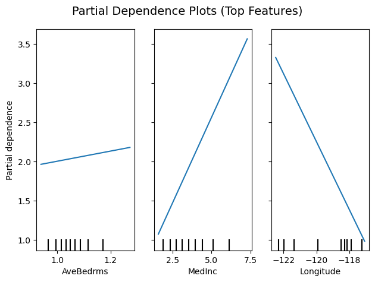

```
🧠 Interpretation:
- These plots show how the predicted value of 'MedHouseVal' changes when one feature increases, while holding others fixed.
  • As 'AveBedrms' increases, observe whether 'MedHouseVal' rises, falls, or stays flat — this shows its individual effect.
  • As 'MedInc' increases, observe whether 'MedHouseVal' rises, falls, or stays flat — this shows its individual effect.
  • As 'Longitude' increases, observe whether 'MedHouseVal' rises, falls, or stays flat — this shows its individual effect.
- A flat curve → minimal impact. A steep or curved slope → strong or non-linear influence.
```

```python
from sklearn.inspection import PartialDependenceDisplay

# Pick top 2–3 features from SHAP or coefficients
top_features = coeff_df["Feature"].head(3).tolist()

# Plot PDP
PartialDependenceDisplay.from_estimator(
    lr, X, features=top_features, kind="average", grid_resolution=50
)
plt.suptitle("Partial Dependence Plots (Top Features)", fontsize=14)
plt.tight_layout()
plt.show()

# Business interpretation — tailored to dataset
print("🧠 Interpretation:")
print(f"- These plots show how the predicted value of '{target_col}' changes when one feature increases, while holding others fixed.")
for feature in top_features:
    print(f"  • As '{feature}' increases, observe whether '{target_col}' rises, falls, or stays flat — this shows its individual effect.")
print("- A flat curve → minimal impact. A steep or curved slope → strong or non-linear influence.")
```

### 🧊 Algorithms - Ridge Regression

**📖 Click to Expand - Regularized Regression**

- Regularized regression is like **linear regression with guardrails** — it helps prevent overfitting and improves generalization.
- It’s especially useful when:
  - You have **many features**, some of which may be noisy or redundant.
  - There's **multicollinearity** (features are correlated).
  - The model performs **too well on training but poorly on test data**.
- There are 3 main types:
  - **Ridge**: Shrinks coefficients, but keeps all features
  - **Lasso**: Shrinks some coefficients all the way to zero → does feature selection
  - **ElasticNet**: A mix of both
- Use regularization when your model has **high variance** or you want to **simplify** the feature set.

**📖 Click to Expand - Ridge Regression**

- **Ridge regression** adds a penalty that discourages large coefficients.
- It’s useful when all features are important but may be correlated.

**Objective function:**  
$\text{Loss} = \sum (y_i - \hat{y}_i)^2 + \lambda \sum \beta_j^2$

- The penalty term $\lambda \sum \beta_j^2$ shrinks coefficients without zeroing them out.
- This reduces overfitting but **keeps all features** in the model.
- Works well when you want to **retain information** while controlling variance.

**📖 Click to Expand - Suitability Checklist**

| Criterion | Comment |
| --- | --- |
| **Interpretability** | ⚠️ Moderate – coefficients interpretable, but shrunk due to L2 penalty |
| **Linearity Expectation** | ✅ Yes – assumes linear relationship between features and target |
| **High dimensionality** | ✅ Good – handles many features with L2 regularization |
| **Handling of multicollinearity** | ✅ Good – L2 penalty reduces impact of correlated features |
| **Handling of categorical features** | ❌ Requires encoding – use one-hot or ordinal encoding |
| **Handling of outliers** | ❌ Sensitive – does not explicitly handle outliers |
| **Handling of missing values** | ❌ Not supported – requires imputation |
| **Scaling of features needed** | ✅ Yes – regularization depends on feature magnitude |
| **Handling of sparseness in data** | ⚠️ Moderate – doesn't zero out coefficients, better with dense data |
| **Skewed target distribution** | ⚠️ Assumes homoscedasticity – performance may drop on skewed targets |
| **Assumes normality of residuals?** | ✅ Yes – for valid inference and confidence intervals |

- **General comment on accuracy**: ✅ Often better than linear regression when multicollinearity is present
- **General comment on training speed**: ✅ Fast – nearly as efficient as linear regression

```python
from sklearn.linear_model import Ridge

ridge = Ridge(alpha=1.0)
ridge.fit(X_train, y_train)

y_ridge_train = ridge.predict(X_train)
y_ridge_test = ridge.predict(X_test)

print("🔧 Ridge Regression")
print(f"Train R²: {r2_score(y_train, y_ridge_train):.3f}")
print(f"Test  R²: {r2_score(y_test, y_ridge_test):.3f}")
print(f"Test  MAE: {mean_absolute_error(y_test, y_ridge_test):.2f}")
```

```
Ridge()
```

```
🔧 Ridge Regression
Train R²: 0.610
Test  R²: 0.591
Test  MAE: 0.53
```

### 🔥 Algorithms - Lasso Regression

**📖 Click to Expand**

- **Lasso regression** adds a penalty on the **absolute values** of coefficients.
- It helps with **feature selection** by shrinking some coefficients to exactly zero.

**Objective function:**  
$\text{Loss} = \sum (y_i - \hat{y}_i)^2 + \lambda \sum |\beta_j|$

- The $L1$ penalty encourages **sparsity** — only the most important features survive.
- Use Lasso when you suspect some features **don’t matter** or want a **simpler model**.

**📖 Click to Expand - Suitability Checklist**

| Criterion | Comment |
| --- | --- |
| **Interpretability** | ⚠️ Moderate – less interpretable due to variable shrinkage, but aids feature selection |
| **Linearity Expectation** | ✅ Yes – assumes linear relationship between features and target |
| **High dimensionality** | ✅ Very good – performs implicit feature selection via L1 penalty |
| **Handling of multicollinearity** | ⚠️ Partial – tends to pick one feature among correlated ones |
| **Handling of categorical features** | ❌ Requires encoding – one-hot or ordinal encoding needed |
| **Handling of outliers** | ❌ Sensitive – does not explicitly handle outliers |
| **Handling of missing values** | ❌ Not supported – requires imputation |
| **Scaling of features needed** | ✅ Yes – essential due to L1 penalty sensitivity |
| **Handling of sparseness in data** | ✅ Good – promotes sparsity in coefficients, useful for sparse signals |
| **Skewed target distribution** | ⚠️ Assumes homoscedasticity – not ideal for highly skewed targets |
| **Assumes normality of residuals?** | ✅ Yes – for statistical inference, if needed post-selection |

- **General comment on accuracy**: ✅ Strong when only a subset of features are useful; acts as model + selector
- **General comment on training speed**: ✅ Fast for small to medium datasets; slower with very high dimensionality

```python
from sklearn.linear_model import Lasso

lasso = Lasso(alpha=0.1)
lasso.fit(X_train, y_train)

y_lasso_train = lasso.predict(X_train)
y_lasso_test = lasso.predict(X_test)

print("🔥 Lasso Regression")
print(f"Train R²: {r2_score(y_train, y_lasso_train):.3f}")
print(f"Test  R²: {r2_score(y_test, y_lasso_test):.3f}")
print(f"Test  MAE: {mean_absolute_error(y_test, y_lasso_test):.2f}")
```

```
Lasso(alpha=0.1)
```

```
🔥 Lasso Regression
Train R²: 0.546
Test  R²: 0.544
Test  MAE: 0.58
```

### 🧃 Algorithms - ElasticNet

**📖 Click to Expand**

- **ElasticNet** blends Ridge (L2) and Lasso (L1) penalties.
- It balances **stability and sparsity** — best when you're not sure which to use.

**Objective function:**  
$\text{Loss} = \sum (y_i - \hat{y}_i)^2 + \lambda_1 \sum |\beta_j| + \lambda_2 \sum \beta_j^2$

- The L1 part helps with **feature selection**, while L2 improves **stability**.
- ElasticNet is often used as a **default choice** when working with many features.

**📖 Click to Expand - Suitability Checklist**

| Criterion | Comment |
| --- | --- |
| **Interpretability** | ⚠️ Moderate – coefficients are shrunk and partially zeroed; harder to interpret |
| **Linearity Expectation** | ✅ Yes – assumes linear relationship between features and target |
| **High dimensionality** | ✅ Excellent – handles many features well, especially when correlated |
| **Handling of multicollinearity** | ✅ Better than Lasso – distributes weight across correlated features |
| **Handling of categorical features** | ❌ Requires encoding – one-hot or ordinal encoding needed |
| **Handling of outliers** | ❌ Sensitive – still affected by extreme values |
| **Handling of missing values** | ❌ Not supported – requires imputation |
| **Scaling of features needed** | ✅ Yes – critical due to combined penalties |
| **Handling of sparseness in data** | ✅ Good – promotes sparsity but more stable than Lasso alone |
| **Skewed target distribution** | ⚠️ Assumes homoscedasticity – not ideal for skewed distributions |
| **Assumes normality of residuals?** | ✅ Yes – standard inference assumptions apply post-selection |

- **General comment on accuracy**: ✅ Flexible – performs well when features are correlated and some sparsity is expected
- **General comment on training speed**: ⚠️ Slower than Ridge/Lasso – due to tuning two hyperparameters (`alpha`, `l1_ratio`)

```python
from sklearn.linear_model import ElasticNet

elastic = ElasticNet(alpha=0.1, l1_ratio=0.5)
elastic.fit(X_train, y_train)

y_elastic_train = elastic.predict(X_train)
y_elastic_test = elastic.predict(X_test)

print("🧃 ElasticNet Regression")
print(f"Train R²: {r2_score(y_train, y_elastic_train):.3f}")
print(f"Test  R²: {r2_score(y_test, y_elastic_test):.3f}")
print(f"Test  MAE: {mean_absolute_error(y_test, y_elastic_test):.2f}")
```

```
ElasticNet(alpha=0.1)
```

```
🧃 ElasticNet Regression
Train R²: 0.576
Test  R²: 0.575
Test  MAE: 0.55
```

### 🌳 Algorithms - Decision Trees

**📖 Click to Expand**

- A **Decision Tree** is a non-linear model that splits the data into subsets based on feature values. It recursively divides the dataset into branches, making decisions at each node based on a feature threshold.

**How it works:**

- **Splitting**: The tree splits data into two groups based on a feature and its value. The objective is to find splits that result in the most homogeneous subsets.
- **Node**: Each node represents a decision rule (e.g., "Is `AveRooms` > 6?").
- **Leaf**: A leaf node represents the predicted value (for regression) or class label (for classification).
- **Tree Construction**: The tree is built by recursively finding the best feature and value to split the data, using metrics like **Gini impurity**, **information gain**, or **mean squared error (MSE)**.

**Equation (Regression Tree):**  
For regression trees, the predicted value at a leaf node is the mean of the target values in that subset.

$\hat{y} = \frac{1}{n} \sum_{i=1}^{n} y_i$

**Objective:**  
Minimize the impurity at each split. For regression, the goal is to minimize the sum of squared errors within the branches.

**In business terms:**  
A decision tree breaks down a complex problem into simple, easy-to-understand decisions. It’s like following a series of “yes/no” questions that guide you to the right answer.

**📖 Click to Expand - Suitability Checklist**

| Criterion | Comment |
| --- | --- |
| **Interpretability** | ✅ Good – tree structure is easy to visualize and explain |
| **Linearity Expectation** | ✅ No – captures complex non-linear relationships naturally |
| **High dimensionality** | ⚠️ Moderate – prone to overfitting with many features unless pruned |
| **Handling of multicollinearity** | ✅ Handles – splits on strongest feature; ignores others |
| **Handling of categorical features** | ⚠️ Requires encoding – label encoding preferred; not ideal with high-cardinality |
| **Handling of outliers** | ✅ Robust – splits based on thresholds, not influenced by extreme values |
| **Handling of missing values** | ⚠️ Partial – some implementations handle them natively, others require imputation |
| **Scaling of features needed** | ✅ Not needed – trees are scale-invariant |
| **Handling of sparseness in data** | ⚠️ Limited – not ideal for very sparse matrices like bag-of-words |
| **Skewed target distribution** | ✅ Handles well – no distributional assumptions |
| **Assumes normality of residuals?** | ❌ No – non-parametric, no residual distribution assumption |

- **General comment on accuracy**: ⚠️ Can overfit – strong on small to medium data, weaker alone on complex patterns
- **General comment on training speed**: ✅ Fast – efficient even on large datasets with moderate depth

### 🪵 Algorithms - Random Forests

**📖 Click to Expand**

A **Random Forest** is an ensemble learning method that creates multiple decision trees and combines their predictions to improve accuracy and reduce overfitting.

##### How it works:

- **Bootstrap Aggregating (Bagging)**: Random Forests use bootstrapping to create multiple subsets of the data. Each tree is trained on a random subset (with replacement) of the data, which introduces diversity in the models.
- **Tree Construction**: Each tree in the forest is trained independently, using a random subset of features for each split. This randomness helps prevent overfitting and ensures that trees do not correlate too much with each other.
- **Voting/Averaging**: For regression tasks, the final prediction is the **average** of all tree predictions. For classification tasks, it’s the **mode** (most frequent class) predicted by the trees.

##### Equation (for Regression):

For regression, the predicted value is the average of the predictions from all trees.

$\hat{y} = \frac{1}{M} \sum_{i=1}^{M} \hat{y}_i$

Where:

- **$\hat{y}_i$**: Prediction of the i-th tree
- **$M$**: Total number of trees in the forest

##### **Objective:**

Minimize the variance of the model’s predictions by averaging over many trees, each trained on a different subset of the data.

**📖 Click to Expand - Suitability Checklist**

| Criterion | Comment |
| --- | --- |
| **Interpretability** | ❌ Low – individual trees are interpretable, but the ensemble is not |
| **Linearity Expectation** | ✅ No – models complex non-linear relationships naturally |
| **High dimensionality** | ✅ Good – handles many features well via random feature selection |
| **Handling of multicollinearity** | ✅ Handles – less sensitive due to randomized feature selection in each tree |
| **Handling of categorical features** | ⚠️ Requires encoding – typically label encoding; not optimal with high-cardinality |
| **Handling of outliers** | ✅ Robust – ensemble effect reduces outlier influence |
| **Handling of missing values** | ⚠️ Partial – some implementations support it; others need imputation |
| **Scaling of features needed** | ✅ Not needed – tree-based and scale-invariant |
| **Handling of sparseness in data** | ⚠️ Moderate – performs okay, but not best for highly sparse data |
| **Skewed target distribution** | ✅ Handles – no assumption about target distribution |
| **Assumes normality of residuals?** | ❌ No – fully non-parametric model |

- **General comment on accuracy**: ✅ Strong – often top-tier performance on structured/tabular data
- **General comment on training speed**: ⚠️ Slower than single models – but parallelizable and scalable

### 🚀 Algorithms - Gradient Boosting (XGBoost, LightGBM)

**📖 Click to Expand**

- **Gradient Boosting** is an ensemble learning technique that builds models sequentially, where each model corrects the errors made by the previous one. The algorithm focuses on minimizing the **loss function** by adding trees that improve the model’s performance in areas where it’s struggling.

**How it works:**

- **Boosting**: Unlike Random Forests, which train trees independently, Gradient Boosting trains trees **sequentially**. Each tree corrects the residual errors of the previous one by focusing on the examples that were misclassified or poorly predicted.
- **Gradient Descent**: The model uses **gradient descent** to minimize the loss function, optimizing the model step-by-step. The error of the current model is propagated back through the model to update the next tree.
- **Learning Rate**: A key parameter in Gradient Boosting is the **learning rate**. It controls how much each new tree is allowed to influence the final model. A lower learning rate often results in better generalization but requires more trees to achieve the same level of performance.
- **XGBoost/LightGBM**: These are highly optimized versions of Gradient Boosting. **XGBoost** (Extreme Gradient Boosting) and **LightGBM** (Light Gradient Boosting Machine) offer faster training, better regularization, and enhanced performance, especially on large datasets.

**Objective:**  
Minimize the **loss function** (such as mean squared error for regression) through iterative corrections. Each new tree learns from the residuals (errors) of the previous tree.

**In business terms:**  
Gradient Boosting works like hiring a new team member who focuses on fixing the mistakes made by the previous team member. Over time, as more team members are added, the overall performance improves dramatically by addressing areas of weakness.

**📖 Click to Expand - Suitability Checklist**

| Criterion | Comment |
| --- | --- |
| **Interpretability** | ❌ Low – ensembles are complex; interpretability requires SHAP or similar tools |
| **Linearity Expectation** | ✅ No – captures highly non-linear relationships |
| **High dimensionality** | ✅ Excellent – handles large feature sets with built-in feature importance and regularization |
| **Handling of multicollinearity** | ✅ Robust – tends to pick one feature among correlated ones; not harmed significantly |
| **Handling of categorical features** | ⚠️ Requires encoding – label encoding usually sufficient; LightGBM supports native categorical handling |
| **Handling of outliers** | ✅ Robust – tree splits reduce outlier influence significantly |
| **Handling of missing values** | ✅ Supported – both XGBoost and LightGBM handle missing values natively during tree construction |
| **Scaling of features needed** | ✅ Not needed – models are scale-invariant |
| **Handling of sparseness in data** | ✅ Excellent – built-in support for sparse data (e.g., in XGBoost and LightGBM) |
| **Skewed target distribution** | ✅ Handles well – flexible enough to model skewed targets without assumptions |
| **Assumes normality of residuals?** | ❌ No – fully non-parametric, no assumptions on residual distribution |

- **General comment on accuracy**: ✅ Top-tier – often best-in-class for structured/tabular regression problems
- **General comment on training speed**: ⚠️ Slower than simpler models – but optimized and scalable (especially with LightGBM and GPU support)

### ⚙️ Algorithms - Support Vector Machines (SVR)

**📖 Click to Expand**

- **Support Vector Machines (SVM)** for regression (SVR) is a powerful algorithm that attempts to find a **hyperplane** that best fits the data while allowing for some margin of error. The idea is to maximize the margin between the data points and the hyperplane while keeping the model complexity low.

**How it works:**

- **Maximizing the Margin**: The SVR model searches for a hyperplane that not only separates the data points but also ensures that the margin between the data points and the hyperplane is maximized.
- **Epsilon-Insensitive Loss**: In SVR, the margin of error is controlled by a parameter called **epsilon**. Points that lie within this margin are considered as correctly predicted, while points outside the margin are penalized.
- **Kernel Trick**: SVR can be extended to non-linear regression by using the **kernel trick**. This allows SVR to operate in a high-dimensional space, making it capable of handling complex, non-linear relationships.
  - Common kernels include the **linear**, **polynomial**, and **radial basis function (RBF)** kernels.

**Objective:**  
Minimize the regularized loss function, which penalizes data points that lie outside the epsilon margin and tries to find the optimal hyperplane.

**In business terms:**  
SVR works like finding the best-fit line (or hyperplane) that approximates the data while allowing some flexibility for errors. The goal is to minimize prediction errors while ensuring that the model is not overly sensitive to small variations.

**📖 Click to Expand - Suitability Checklist**

| Criterion | Comment |
| --- | --- |
| **Interpretability** | ❌ Low – lacks clear coefficients or rule-based structure |
| **Linearity Expectation** | ⚠️ Depends – linear SVR assumes linearity; kernel SVR handles non-linear patterns |
| **High dimensionality** | ✅ Very good – effective in high-dimensional spaces, especially with appropriate kernels |
| **Handling of multicollinearity** | ⚠️ Somewhat handles – regularization helps, but not designed to resolve multicollinearity explicitly |
| **Handling of categorical features** | ❌ Not supported natively – requires proper encoding and kernel compatibility |
| **Handling of outliers** | ❌ Sensitive – margin-based loss can be distorted by outliers |
| **Handling of missing values** | ❌ Not supported – must impute missing data beforehand |
| **Scaling of features needed** | ✅ Yes – essential for stable and effective optimization (especially with RBF kernel) |
| **Handling of sparseness in data** | ✅ Good – works well in sparse high-dimensional cases (e.g., text with linear kernel) |
| **Skewed target distribution** | ⚠️ Handles better than OLS, but predictions are bounded by ε-margin; tuning required |
| **Assumes normality of residuals?** | ❌ No – non-parametric and does not rely on residual distribution assumptions |

- **General comment on accuracy**: ✅ High – strong performance with well-tuned kernel and hyperparameters
- **General comment on training speed**: ❌ Slow – especially with large datasets or non-linear kernels

### 🧠 Algorithms - K-Nearest Neighbors (KNN)

**📖 Click to Expand**

- **K-Nearest Neighbors (KNN)** is a simple, non-parametric algorithm used for both classification and regression. The algorithm makes predictions based on the **k** closest training samples in the feature space. The idea is that similar data points are likely to have similar target values.

**How it works:**

- **Distance Metric**: KNN calculates the **distance** between the query point and all the points in the dataset. Common distance metrics include **Euclidean**, **Manhattan**, and **Minkowski** distances.
- **Prediction for Regression**: In **KNN regression**, the prediction is the **average** of the target values of the **k** nearest neighbors.
  - For example, if `k=3`, the prediction for a query point is the average of the target values of the three nearest points.
- **Prediction for Classification**: In **KNN classification**, the prediction is determined by the **majority vote** from the k nearest neighbors.
- **Choosing k**: The value of **k** determines how many neighbors are considered. A small value of k can make the model sensitive to noise, while a larger k can smooth the prediction but may miss fine details.

**Objective:**  
Minimize the **prediction error** by considering the closest data points and averaging or voting to generate predictions.

**In business terms:**  
KNN works like asking your closest neighbors for advice. The final decision is based on the majority opinion or average of your nearest peers. It's simple but effective when the data is well-structured and doesn't have too many dimensions (features).

**📖 Click to Expand - Suitability Checklist**

| Criterion | Comment |
| --- | --- |
| **Interpretability** | ⚠️ Moderate – intuitive to explain, but no learned model or coefficients |
| **Linearity Expectation** | ✅ No – models non-linear patterns based on local neighborhoods |
| **High dimensionality** | ❌ Poor – suffers from the curse of dimensionality; distance metrics lose meaning |
| **Handling of multicollinearity** | ❌ Problematic – redundant features distort distance-based similarity |
| **Handling of categorical features** | ❌ Not natively supported – requires encoding and careful distance handling |
| **Handling of outliers** | ❌ Sensitive – local predictions easily skewed by nearby outliers |
| **Handling of missing values** | ❌ Not supported – requires complete cases or imputation beforehand |
| **Scaling of features needed** | ✅ Yes – crucial, since all predictions are based on distance |
| **Handling of sparseness in data** | ❌ Poor – sparse vectors make nearest neighbor distances unreliable |
| **Skewed target distribution** | ⚠️ Affected – highly skewed targets can lead to biased local averages |
| **Assumes normality of residuals?** | ❌ No – non-parametric, no assumptions on residuals or distributions |

- **General comment on accuracy**: ⚠️ Variable – performs well with clean, low-dimensional, dense data; poor elsewhere
- **General comment on training speed**: ✅ Fast training (lazy learner), ❌ Slow inference – computes distances at prediction time

### 🤖 Algorithms - Neural Networks (MLP Regressor)

**📖 Click to Expand**

- **Neural Networks (MLP Regressor)** are a class of machine learning algorithms inspired by the structure and functioning of the human brain. The **Multilayer Perceptron (MLP)** is a feedforward neural network that consists of multiple layers of neurons, including an input layer, one or more hidden layers, and an output layer.

**How it works:**

- **Neurons**: Each neuron receives input from previous layers, applies a weighted sum of the inputs, adds a bias, and then passes the result through an **activation function** (e.g., ReLU, Sigmoid, Tanh).
- **Forward Propagation**: During training, data passes through the network from input to output. The predicted output is compared to the true target, and the error is computed.
- **Backpropagation**: The error is propagated back through the network to adjust the weights and biases of the neurons, using an optimization algorithm like **Stochastic Gradient Descent (SGD)** or **Adam**.
- **Layers**: The hidden layers allow the network to model complex, non-linear relationships between input features and the target variable.

**Objective:**  
Minimize the **loss function** (e.g., Mean Squared Error for regression) by adjusting the weights and biases of the neurons through backpropagation, using optimization techniques.

**In business terms:**  
Neural Networks can be thought of as a highly flexible system capable of learning complex patterns. The deeper the network (i.e., the more layers), the better it can capture intricate relationships in the data, much like how the human brain processes and learns from experience.

Back to the top

# 📊 Model Selection

**📖 Click to Expand - Model Choice**

##### 🧠 Regression Model Selection Table (Based on Data Characteristics)

[output not shown]

**📖 Click to Expand - Model Choice FlowChart**

##### 🧠 Model Selection Flowchart (Based on Data Characteristics)

[output not shown]

#### 🧠 Recommend Models

```python
# Import necessary libraries for regression models
from sklearn.linear_model import LinearRegression, Ridge, Lasso, ElasticNet
from sklearn.tree import DecisionTreeRegressor
from sklearn.ensemble import RandomForestRegressor, GradientBoostingRegressor
from sklearn.svm import SVR
from sklearn.neighbors import KNeighborsRegressor
from sklearn.neural_network import MLPRegressor
import xgboost as xgb

model_registry = {
    "LinearRegression": LinearRegression(),
    "Ridge": Ridge(),
    "Lasso": Lasso(),
    "ElasticNet": ElasticNet(),
    "DecisionTreeRegressor": DecisionTreeRegressor(),
    "RandomForestRegressor": RandomForestRegressor(),
    "GradientBoostingRegressor": GradientBoostingRegressor(),
    "XGBRegressor": xgb.XGBRegressor(),
    "KNeighborsRegressor": KNeighborsRegressor(), # K-Nearest Neighbors (KNN)
    "SVR": SVR(), # Support Vector Regression
    "MLPRegressor": MLPRegressor(max_iter=1000) # Neural Network
}
```

```python
def recommend_models_prediction(data_characteristics, verbose=True):
    """
    Scores and ranks prediction models (for regression or other prediction tasks) based on data characteristics.
    Prints the recommended order and rationales.
    """
    from termcolor import colored

    score = {}
    rationale = {}

    # Extract characteristics
    target_info = data_characteristics.get("target_variable", {})
    feature_info = data_characteristics.get("features", {})
    is_linear = data_characteristics.get("relationships", {}).get("feature_target_linear_relationships", {})

    imbalance = target_info.get("imbalance", False)
    feature_type = feature_info.get("type", "")
    corr = feature_info.get("correlation", "")
    outliers = feature_info.get("outliers", False)
    multicollinearity = feature_info.get("multicollinearity", False)

    # --- Linear Regression ---
    score["LinearRegression"] = 2
    rationale["LinearRegression"] = ["Good for linear relationships"]
    if all(is_linear.values()):
        score["LinearRegression"] += 3
        rationale["LinearRegression"].append("Linear relationships between features and target")
    if feature_type == "continuous":
        score["LinearRegression"] += 1
        rationale["LinearRegression"].append("Features are continuous")
    if outliers:
        score["LinearRegression"] -= 1
        rationale["LinearRegression"].append("Sensitive to outliers")

    # --- Ridge Regression ---
    score["Ridge"] = 3
    rationale["Ridge"] = ["Handles collinearity well"]
    if multicollinearity:
        score["Ridge"] += 2
        rationale["Ridge"].append("Features are correlated (multicollinearity)")
    if outliers:
        score["Ridge"] -= 1
        rationale["Ridge"].append("Sensitive to outliers")

    # --- Lasso Regression ---
    score["Lasso"] = 2
    rationale["Lasso"] = ["Performs feature selection"]
    if multicollinearity:
        score["Lasso"] += 1
        rationale["Lasso"].append("Can handle correlated features with L1 regularization")
    if outliers:
        score["Lasso"] -= 1
        rationale["Lasso"].append("Sensitive to outliers")

    # --- ElasticNet ---
    score["ElasticNet"] = 3
    rationale["ElasticNet"] = ["Good balance between Ridge and Lasso"]
    if multicollinearity:
        score["ElasticNet"] += 2
        rationale["ElasticNet"].append("Can handle collinearity well with both L1 and L2 regularization")
    if outliers:
        score["ElasticNet"] -= 1
        rationale["ElasticNet"].append("Sensitive to outliers")

    # --- Decision Tree Regressor ---
    score["DecisionTreeRegressor"] = 3
    rationale["DecisionTreeRegressor"] = ["Handles non-linear relationships"]
    if outliers:
        score["DecisionTreeRegressor"] += 1
        rationale["DecisionTreeRegressor"].append("Robust to outliers")
    if multicollinearity:
        score["DecisionTreeRegressor"] += 1
        rationale["DecisionTreeRegressor"].append("Can handle correlated features")

    # --- Random Forest Regressor ---
    score["RandomForestRegressor"] = 4
    rationale["RandomForestRegressor"] = ["Handles non-linear relationships, robust to outliers"]
    if outliers:
        score["RandomForestRegressor"] += 1
        rationale["RandomForestRegressor"].append("Robust to outliers")
    if imbalance:
        score["RandomForestRegressor"] += 1
        rationale["RandomForestRegressor"].append("Bootstrap helps with imbalance")

    # --- Gradient Boosting Regressor ---
    score["GradientBoostingRegressor"] = 4
    rationale["GradientBoostingRegressor"] = ["Strong performance for non-linear relationships"]
    if outliers:
        score["GradientBoostingRegressor"] += 1
        rationale["GradientBoostingRegressor"].append("Robust to outliers")
    if imbalance:
        score["GradientBoostingRegressor"] += 1
        rationale["GradientBoostingRegressor"].append("Boosting handles imbalance well")

    # --- XGBoost ---
    score["XGBRegressor"] = 5
    rationale["XGBRegressor"] = ["Strong general-purpose model, robust to outliers and imbalance"]
    if outliers:
        score["XGBRegressor"] += 1
        rationale["XGBRegressor"].append("Robust to outliers")
    if imbalance:
        score["XGBRegressor"] += 1
        rationale["XGBRegressor"].append("scale_pos_weight helps with imbalance")
    if multicollinearity:
        score["XGBRegressor"] += 1
        rationale["XGBRegressor"].append("Handles redundant features well")

    # --- K-Nearest Neighbors (KNN) ---
    score["KNeighborsRegressor"] = 2
    rationale["KNeighborsRegressor"] = ["Simple, distance-based"]
    if feature_type == "continuous":
        score["KNeighborsRegressor"] += 1
        rationale["KNeighborsRegressor"].append("Distance-based → works better on continuous features")
    if outliers:
        score["KNeighborsRegressor"] -= 2
        rationale["KNeighborsRegressor"].append("Sensitive to outliers")

    # --- Neural Network (MLP Regressor) ---
    score["MLPRegressor"] = 3
    rationale["MLPRegressor"] = ["Flexible model for complex relationships"]
    if imbalance:
        score["MLPRegressor"] += 1
        rationale["MLPRegressor"].append("Can learn from imbalance with tuning")
    if outliers:
        score["MLPRegressor"] -= 1
        rationale["MLPRegressor"].append("Sensitive to outliers")

    # Sort by descending score
    ranked_models = sorted(score.items(), key=lambda x: x[1], reverse=True)
    ranked_model_names = [model for model, _ in ranked_models]

    # Filter and reorder model_registry based on ranking
    ranked_registry = {name: model_registry[name] for name in ranked_model_names if name in model_registry}

    if verbose:
        print("🚀 Recommended Model Evaluation Order:\n")
        for i, name in enumerate(ranked_model_names, 1):
            if name in model_registry:
                prefix = colored(f"{i}. {name} (Score: {score[name]})", "green") if i <= 3 else f"{i}. {name} (Score: {score[name]})"
                print(prefix)
                for reason in rationale[name]:
                    print(f"   ↪ {reason}")
        print()

    return ranked_model_names, ranked_registry
```

```python
ranked_model_names, model_registry = recommend_models_prediction(data_characteristics, verbose=True)
" > ".join(ranked_model_names)
```

```
🚀 Recommended Model Evaluation Order:

1. XGBRegressor (Score: 7)
   ↪ Strong general-purpose model, robust to outliers and imbalance
   ↪ Robust to outliers
   ↪ Handles redundant features well
2. DecisionTreeRegressor (Score: 5)
   ↪ Handles non-linear relationships
   ↪ Robust to outliers
   ↪ Can handle correlated features
3. RandomForestRegressor (Score: 5)
   ↪ Handles non-linear relationships, robust to outliers
   ↪ Robust to outliers
4. GradientBoostingRegressor (Score: 5)
   ↪ Strong performance for non-linear relationships
   ↪ Robust to outliers
5. Ridge (Score: 4)
   ↪ Handles collinearity well
   ↪ Features are correlated (multicollinearity)
   ↪ Sensitive to outliers
6. ElasticNet (Score: 4)
   ↪ Good balance between Ridge and Lasso
   ↪ Can handle collinearity well with both L1 and L2 regularization
   ↪ Sensitive to outliers
7. Lasso (Score: 2)
   ↪ Performs feature selection
   ↪ Can handle correlated features with L1 regularization
   ↪ Sensitive to outliers
8. MLPRegressor (Score: 2)
   ↪ Flexible model for complex relationships
   ↪ Sensitive to outliers
9. LinearRegression (Score: 1)
   ↪ Good for linear relationships
   ↪ Sensitive to outliers
10. KNeighborsRegressor (Score: 0)
   ↪ Simple, distance-based
   ↪ Sensitive to outliers
```

```
'XGBRegressor > DecisionTreeRegressor > RandomForestRegressor > GradientBoostingRegressor > Ridge > ElasticNet > Lasso > MLPRegressor > LinearRegression > KNeighborsRegressor'
```

#### 📈 Model Comparison

```python
top_k = 5
for name in list(model_registry.keys())[:top_k][::-1]:
    # We evaluate only the top 3 recommended models (ranked earlier) for focused comparison.
    print(f"\n🔧 Training: {name}")

    # Fit and predict
    model = model_registry[name]
    model.fit(X_train, y_train)
    y_train_pred = model.predict(X_train)
    y_test_pred = model.predict(X_test)

    # Evaluation summary using existing functions
    print(f"Evaluation for {name}:")

    # Evaluation Metrics
    evaluate_model_performance(X_train, y_train, y_train_pred, X_test, y_test, y_test_pred, label=name)

    # Predicted vs Actual
    # plot_predicted_vs_actual(y_test, y_test_pred, title=f"{name} - Test Predicted vs Actual", data_type="Test Data")
    # plot_predicted_vs_actual(y_train, y_train_pred, title=f"{name} - Train Predicted vs Actual", data_type="Train Data")

    # Residual Plot
    # plot_residuals_vs_predicted(y_test, y_test_pred, label="Test Data", plot_qq=True)
    # plot_residuals_vs_predicted(y_train, y_train_pred, label="Train Data", plot_qq=True)

    # Track and log best model
    update_best_model_info(
        model_name=name,
        model_obj=model,
        y_train=y_train,
        y_test=y_test,
        y_train_pred=y_train_pred,
        y_test_pred=y_test_pred
    )

    print("—" * 80)  # horizontal line
```

```
🔧 Training: Ridge
```

```
Ridge()
```

```
Evaluation for Ridge:

🔧 Ridge - Train Performance
R²: 0.610 → Explains 61% of variation in target
Adjusted R²: 0.610
MAPE: 31.49% → On average, we're off by this percentage
MAE: 0.53 → On average, we're off by ±$52953
RMSE: 0.72 → Penalizes big misses more heavily
MSE: 0.52 → Mean squared error

🧪 Ridge - Test Performance
R²: 0.591 → Explains 59% of variation in target
Adjusted R²: 0.590
MAPE: 31.98% → On average, we're off by this percentage
MAE: 0.53 → On average, we're off by ±$52970
RMSE: 0.74 → Penalizes big misses more heavily
MSE: 0.54 → Mean squared error

📌 Interpretation:
- High MAPE → model might need improvement.
- MAE is acceptable; the model is performing well.
- RMSE is acceptable; model is not penalizing large errors excessively.
- R² indicates model fit: 0.59
- Adjusted R² accounts for complexity: 0.59
✅ Ridge just beat previous best (Baseline Model) → r2: -0.0002 → 0.5911
————————————————————————————————————————————————————————————————————————————————

🔧 Training: GradientBoostingRegressor
```

```
GradientBoostingRegressor()
```

```
Evaluation for GradientBoostingRegressor:

🔧 GradientBoostingRegressor - Train Performance
R²: 0.806 → Explains 81% of variation in target
Adjusted R²: 0.806
MAPE: 20.32% → On average, we're off by this percentage
MAE: 0.36 → On average, we're off by ±$35626
RMSE: 0.51 → Penalizes big misses more heavily
MSE: 0.26 → Mean squared error

🧪 GradientBoostingRegressor - Test Performance
R²: 0.781 → Explains 78% of variation in target
Adjusted R²: 0.781
MAPE: 21.68% → On average, we're off by this percentage
MAE: 0.37 → On average, we're off by ±$37125
RMSE: 0.54 → Penalizes big misses more heavily
MSE: 0.29 → Mean squared error

📌 Interpretation:
- High MAPE → model might need improvement.
- MAE is acceptable; the model is performing well.
- RMSE is acceptable; model is not penalizing large errors excessively.
- R² indicates model fit: 0.78
- Adjusted R² accounts for complexity: 0.78
✅ GradientBoostingRegressor just beat previous best (Ridge) → r2: 0.5911 → 0.7809
————————————————————————————————————————————————————————————————————————————————

🔧 Training: RandomForestRegressor
```

```
RandomForestRegressor()
```

```
Evaluation for RandomForestRegressor:

🔧 RandomForestRegressor - Train Performance
R²: 0.973 → Explains 97% of variation in target
Adjusted R²: 0.973
MAPE: 6.91% → On average, we're off by this percentage
MAE: 0.12 → On average, we're off by ±$12382
RMSE: 0.19 → Penalizes big misses more heavily
MSE: 0.04 → Mean squared error

🧪 RandomForestRegressor - Test Performance
R²: 0.808 → Explains 81% of variation in target
Adjusted R²: 0.807
MAPE: 19.10% → On average, we're off by this percentage
MAE: 0.33 → On average, we're off by ±$32840
RMSE: 0.50 → Penalizes big misses more heavily
MSE: 0.25 → Mean squared error

📌 Interpretation:
- High MAPE → model might need improvement.
- MAE is acceptable; the model is performing well.
- RMSE is acceptable; model is not penalizing large errors excessively.
- R² indicates model fit: 0.81
- Adjusted R² accounts for complexity: 0.81
✅ RandomForestRegressor just beat previous best (GradientBoostingRegressor) → r2: 0.7809 → 0.8077
————————————————————————————————————————————————————————————————————————————————

🔧 Training: DecisionTreeRegressor
```

```
DecisionTreeRegressor()
```

```
Evaluation for DecisionTreeRegressor:

🔧 DecisionTreeRegressor - Train Performance
R²: 1.000 → Explains 100% of variation in target
Adjusted R²: 1.000
MAPE: 0.00% → On average, we're off by this percentage
MAE: 0.00 → On average, we're off by ±$0
RMSE: 0.00 → Penalizes big misses more heavily
MSE: 0.00 → Mean squared error

🧪 DecisionTreeRegressor - Test Performance
R²: 0.602 → Explains 60% of variation in target
Adjusted R²: 0.602
MAPE: 26.05% → On average, we're off by this percentage
MAE: 0.47 → On average, we're off by ±$46693
RMSE: 0.73 → Penalizes big misses more heavily
MSE: 0.53 → Mean squared error

📌 Interpretation:
- High MAPE → model might need improvement.
- MAE is acceptable; the model is performing well.
- RMSE is acceptable; model is not penalizing large errors excessively.
- R² indicates model fit: 0.60
- Adjusted R² accounts for complexity: 0.60
⚠️ DecisionTreeRegressor did not improve the best score.
————————————————————————————————————————————————————————————————————————————————

🔧 Training: XGBRegressor
```

```
XGBRegressor(base_score=None, booster=None, callbacks=None,
             colsample_bylevel=None, colsample_bynode=None,
             colsample_bytree=None, device=None, early_stopping_rounds=None,
             enable_categorical=False, eval_metric=None, feature_types=None,
             gamma=None, grow_policy=None, importance_type=None,
             interaction_constraints=None, learning_rate=None, max_bin=None,
             max_cat_threshold=None, max_cat_to_onehot=None,
             max_delta_step=None, max_depth=None, max_leaves=None,
             min_child_weight=None, missing=nan, monotone_constraints=None,
             multi_strategy=None, n_estimators=None, n_jobs=None,
             num_parallel_tree=None, random_state=None, ...)
```

```
Evaluation for XGBRegressor:

🔧 XGBRegressor - Train Performance
R²: 0.947 → Explains 95% of variation in target
Adjusted R²: 0.947
MAPE: 10.80% → On average, we're off by this percentage
MAE: 0.19 → On average, we're off by ±$18888
RMSE: 0.27 → Penalizes big misses more heavily
MSE: 0.07 → Mean squared error

🧪 XGBRegressor - Test Performance
R²: 0.837 → Explains 84% of variation in target
Adjusted R²: 0.836
MAPE: 17.66% → On average, we're off by this percentage
MAE: 0.31 → On average, we're off by ±$30543
RMSE: 0.46 → Penalizes big misses more heavily
MSE: 0.22 → Mean squared error

📌 Interpretation:
- High MAPE → model might need improvement.
- MAE is acceptable; the model is performing well.
- RMSE is acceptable; model is not penalizing large errors excessively.
- R² indicates model fit: 0.84
- Adjusted R² accounts for complexity: 0.84
✅ XGBRegressor just beat previous best (RandomForestRegressor) → r2: 0.8077 → 0.8367
————————————————————————————————————————————————————————————————————————————————
```

```python
# Print current best model based on regression metric (e.g., R², MSE, MAE)
print(f"\n🏆 Best model so far: {best_model_info['name']} "
      f"({success_metric.upper()} = {best_model_info['metrics']['test'][success_metric]:.4f})")

print(f"\n📊 Model Ranking by {success_metric.upper()}:\n")
ranked = sorted(
    model_results.items(),
    key=lambda x: x[1]["metrics"]["test"][success_metric],
    reverse=True
)

for i, (name, result) in enumerate(ranked, 1):
    score = result["metrics"]["test"][success_metric]
    print(f"{i}. {name:<30} {success_metric}: {score:.4f}")
```

```
🏆 Best model so far: XGBRegressor (R2 = 0.8367)

📊 Model Ranking by R2:

1. XGBRegressor                   r2: 0.8367
2. RandomForestRegressor          r2: 0.8077
3. GradientBoostingRegressor      r2: 0.7809
4. DecisionTreeRegressor          r2: 0.6023
5. Ridge                          r2: 0.5911
6. Baseline Model                 r2: -0.0002
```

```python
import plotly.graph_objects as go
import plotly.subplots as sp
import pandas as pd

# Extract test metrics for regression
df_results = pd.DataFrame({
    model_name: data["metrics"]["test"]
    for model_name, data in model_results.items()
}).T

# Metrics you'd like to plot for regression
desired_metrics = ['r2', 'adjusted_r2', 'mse', 'rmse', 'mae', 'mape']

# Filter only those that exist in df_results
metrics = [m for m in desired_metrics if m in df_results.columns]

# Create subplot layout
rows = (len(metrics) + 1) // 2
fig = sp.make_subplots(rows=rows, cols=2, subplot_titles=[m.upper() for m in metrics])

# Plot each available metric
for i, metric in enumerate(metrics):
    row, col = divmod(i, 2)
    fig.add_trace(
        go.Bar(
            x=df_results.index,
            y=df_results[metric],
            name=metric,
            text=pd.to_numeric(df_results[metric], errors="coerce").round(3),
            textposition="auto"
        ),
        row=row+1, col=col+1
    )

fig.update_layout(
    height=300 * rows,
    width=1000,
    title_text="Model Comparison by Regression Metrics",
    showlegend=False
)

fig.show();
```

[output not shown]

#### 📊 Feature Importance

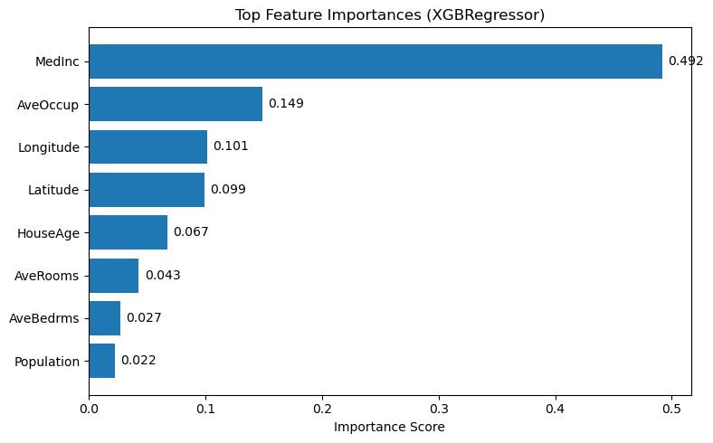

```python
import pandas as pd
import matplotlib.pyplot as plt

def plot_feature_importance(model=None, feature_names=None, top_n=10, model_name=None):
    """
    Plots top N feature importances for regression models.
    Defaults to best_model_info['model'] unless overridden.
    Optionally takes a model_name for the plot title.
    """
    if model is None:
        model = best_model_info["model"]
        model_name = best_model_info.get("name", "Best Model") if model_name is None else model_name
    else:
        model_name = model_name or "Selected Model"

    if feature_names is None:
        feature_names = X_train.columns

    if hasattr(model, "feature_importances_"):  # For tree-based models like Random Forest or XGBoost
        importance = model.feature_importances_
    elif hasattr(model, "coef_"):  # For linear models like Linear Regression, Lasso, Ridge
        importance = model.coef_
    else:
        raise ValueError("Model does not support feature importances or coefficients")

    importance_df = pd.DataFrame({
        "Feature": feature_names,
        "Importance": importance
    }).sort_values(by="Importance", ascending=False).head(top_n)

    plt.figure(figsize=(8, 5))
    plt.barh(importance_df["Feature"][::-1], importance_df["Importance"][::-1])
    for i, (feature, importance) in enumerate(zip(importance_df["Feature"][::-1], importance_df["Importance"][::-1])):
        plt.text(importance + 0.005, i, f"{importance:.3f}", va='center')
    plt.title(f"Top Feature Importances ({model_name})")
    plt.xlabel("Importance Score")
    plt.tight_layout()
    plt.show()

    return list(importance_df["Feature"])

# ✅ Default: plot for best model
imp_ranked = plot_feature_importance()

# 🛠️ Optional: override model + title
# alt_model = model_results["Random Forest"]["model"]
# imp_ranked = plot_feature_importance(model=alt_model, model_name="Random Forest")
```

#### 🧬 SHAP Values

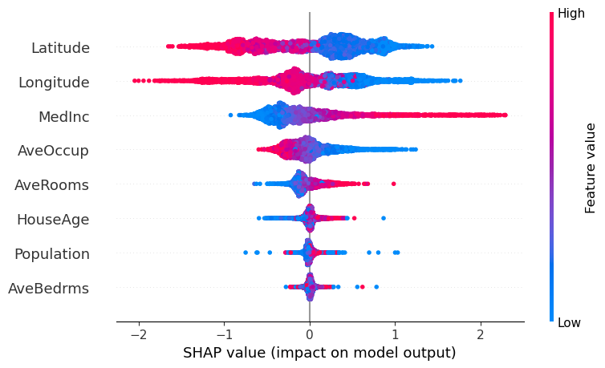

```
📌 SHAP Summary for XGBRegressor:
- Each bar shows how much that feature influences the model’s prediction.
- Features at the top are the most impactful across all predictions.
- Blue/red indicate direction: does the feature push the prediction up or down?
- Helps us understand *why* the model predicts a certain value — not just *what* it predicts.
```

```python
import shap
import numpy as np
import pandas as pd

def plot_shap_summary_tree(model=None, X=None, model_name=None):
    """
    Plot SHAP summary for tree-based regression models (RandomForestRegressor, XGBoost).
    Defaults to best_model_info['model'] and X_test.
    """
    if model is None:
        model = best_model_info["model"]
        model_name = model_name or best_model_info.get("name", "Best Model")
    else:
        model_name = model_name or "Selected Model"

    if X is None:
        X = X_test

    # Use SHAP TreeExplainer for tree-based models
    explainer = shap.TreeExplainer(model)
    shap_values = explainer.shap_values(X)

    # SHAP values for regression are continuous, so no need to index for binary classification
    shap.summary_plot(shap_values, X)

    print(f"\n📌 SHAP Summary for {model_name}:")
    print("- Each bar shows how much that feature influences the model’s prediction.")
    print("- Features at the top are the most impactful across all predictions.")
    print("- Blue/red indicate direction: does the feature push the prediction up or down?")
    print("- Helps us understand *why* the model predicts a certain value — not just *what* it predicts.")

    # Calculate the mean absolute SHAP values for each feature to rank them
    shap_df = pd.DataFrame(np.abs(shap_values), columns=X.columns).mean().sort_values(ascending=False)

    # Return the ranked feature names based on SHAP importance
    return list(shap_df.index)

# ✅ Default: SHAP for best model
shap_ranked = plot_shap_summary_tree()

# 🛠️ Optional: SHAP for any other model
# alt_model = model_results["Random Forest Regressor"]["model"]
# shap_ranked = plot_shap_summary_tree_regression(model=alt_model, model_name="Random Forest Regressor")
```

Back to the top

# 🎯 Fine Tune

**📖 Click to Expand**

- **Hyperparameters** are settings you choose *before* training a model (e.g., how much regularization to apply).
- Unlike model coefficients, hyperparameters aren’t learned from the data — they need to be **tuned** manually or via search.
- In regularized models:
  - `alpha` controls how strong the penalty is
  - A small alpha behaves like linear regression
  - A large alpha shrinks everything too much → underfit

**Why tune?**

- Tuning finds the **best tradeoff** between bias and variance
- Prevents both **underfitting** and **overfitting**
- Improves model generalization on unseen data

You typically use:

- **GridSearchCV**: Tries every combo of values (good for small grids)
- **RandomizedSearchCV**: Tries random combos (faster for large grids)

#### 🧪 Feature Selection – RFE

**📖 Click to Expand**

##### 📊 **What is RFE (Recursive Feature Elimination)?**

RFE is a feature selection technique that helps in identifying the most important features for model performance. It recursively removes the least important features, evaluating model performance at each step.

##### 🔄 **How Does RFE Work?**

- **Model Training**: Initially, the model is trained on **all features**.
- **Feature Ranking**: Features are ranked based on their importance to the model’s performance. The least important ones are eliminated.
- **Recursive Process**: This process continues by recursively removing the least important features and retraining the model.

##### 🔧 **Performance Evaluation**

- The model's performance is evaluated at each step using **R²** or another suitable metric.
- If performance begins to **drop significantly**, the process stops. The number of selected features can be controlled by setting `n_features_to_select`.

##### 🚀 **Why Use RFE?**

- **Improves Model Generalization**: By removing irrelevant or redundant features, RFE helps prevent overfitting.
- **Better Interpretability**: It makes the model more interpretable by focusing on the most important features.
- **Increased Efficiency**: Reducing the number of features helps in building a simpler, faster model.

```python
from sklearn.feature_selection import RFE
from sklearn.metrics import r2_score
import numpy as np

def perform_rfe_with_evaluation(model, X_train, y_train, X_test, y_test, n_features_to_select_range=None):
    """
    Perform Recursive Feature Elimination (RFE) for feature selection and evaluate performance.

    Parameters:
    - model: The regression model to use (e.g., RandomForestRegressor, LinearRegression).
    - X_train: Training data (features).
    - y_train: Training data (target variable).
    - X_test: Test data (features).
    - y_test: Test data (target variable).
    - n_features_to_select_range: Range of number of features to select. If None, it will try selecting all features.

    Returns:
    - best_selected_features: List of features that result in the best performance.
    """
    if n_features_to_select_range is None:
        n_features_to_select_range = range(1, X_train.shape[1] + 1)

    best_score = -np.inf
    best_selected_features = None
    score_history = []

    # Loop through different feature counts to find the best number of features
    for n_features in n_features_to_select_range:
        rfe = RFE(estimator=model, n_features_to_select=n_features)
        rfe.fit(X_train, y_train)

        # Get selected features
        selected_features = X_train.columns[rfe.support_]

        # Drop unselected features from the dataset
        X_train_selected = X_train[selected_features]
        X_test_selected = X_test[selected_features]

        # Train the model with the selected features
        model.fit(X_train_selected, y_train)
        y_test_pred = model.predict(X_test_selected)

        # Evaluate model performance (using R² or other metrics)
        current_score = r2_score(y_test, y_test_pred)
        score_history.append((n_features, current_score))

        # If the current score is better, update the best model info
        if current_score > best_score:
            best_score = current_score
            best_selected_features = selected_features

        print(f"Selected {n_features} features → R²: {current_score:.4f}")

    # Store the best model with the optimal number of features
    print(f"\n🎯 Best features selection: {len(best_selected_features)} features → R²: {best_score:.4f}")

    # Return the best selected features and the score history
    return best_selected_features, score_history
```

```python
# Assuming the best model is stored in best_model_info["model"]
best_model = best_model_info["model"]

# Perform RFE with evaluation to find the best number of features
best_selected_features, score_history = perform_rfe_with_evaluation(
    best_model, X_train, y_train, X_test, y_test, n_features_to_select_range=range(1, 11)
)
```

```
Selected 1 features → R²: 0.4765
Selected 2 features → R²: 0.5590
Selected 3 features → R²: 0.7033
Selected 4 features → R²: 0.8300
Selected 5 features → R²: 0.8356
Selected 6 features → R²: 0.8401
Selected 7 features → R²: 0.8359
Selected 8 features → R²: 0.8367
Selected 9 features → R²: 0.8367
Selected 10 features → R²: 0.8367

🎯 Best features selection: 6 features → R²: 0.8401
```

```python
# Ensure that we use only the best selected features for both train and test data
X_train_selected = X_train[best_selected_features]
X_test_selected = X_test[best_selected_features]

# Now train and evaluate the model using the selected features
best_model.fit(X_train_selected, y_train)
y_train_pred = best_model.predict(X_train_selected)
y_test_pred = best_model.predict(X_test_selected)

evaluate_model_performance(X_train_selected, y_train, y_train_pred, X_test_selected, y_test, y_test_pred, label="Best Model After RFE")
# plot_predicted_vs_actual(y_test, y_test_pred, title="Best Model After RFE - Test Predicted vs Actual", data_type="Test Data")
# plot_residuals_vs_predicted(y_test, y_test_pred, label="Test Data", plot_qq=True)

update_best_model_info(
    model_name="Best Model After RFE",
    model_obj=best_model,
    y_train=y_train,
    y_test=y_test,
    y_train_pred=y_train_pred,
    y_test_pred=y_test_pred,
    mask=True
)
```

```
XGBRegressor(base_score=None, booster=None, callbacks=None,
             colsample_bylevel=None, colsample_bynode=None,
             colsample_bytree=None, device=None, early_stopping_rounds=None,
             enable_categorical=False, eval_metric=None, feature_types=None,
             gamma=None, grow_policy=None, importance_type=None,
             interaction_constraints=None, learning_rate=None, max_bin=None,
             max_cat_threshold=None, max_cat_to_onehot=None,
             max_delta_step=None, max_depth=None, max_leaves=None,
             min_child_weight=None, missing=nan, monotone_constraints=None,
             multi_strategy=None, n_estimators=None, n_jobs=None,
             num_parallel_tree=None, random_state=None, ...)
```

```
🔧 Best Model After RFE - Train Performance
R²: 0.941 → Explains 94% of variation in target
Adjusted R²: 0.941
MAPE: 11.23% → On average, we're off by this percentage
MAE: 0.20 → On average, we're off by ±$19613
RMSE: 0.28 → Penalizes big misses more heavily
MSE: 0.08 → Mean squared error

🧪 Best Model After RFE - Test Performance
R²: 0.840 → Explains 84% of variation in target
Adjusted R²: 0.840
MAPE: 17.49% → On average, we're off by this percentage
MAE: 0.30 → On average, we're off by ±$30477
RMSE: 0.46 → Penalizes big misses more heavily
MSE: 0.21 → Mean squared error

📌 Interpretation:
- High MAPE → model might need improvement.
- MAE is acceptable; the model is performing well.
- RMSE is acceptable; model is not penalizing large errors excessively.
- R² indicates model fit: 0.84
- Adjusted R² accounts for complexity: 0.84
✅ Best Model After RFE just beat previous best (XGBRegressor) → r2: 0.8367 → 0.8401
```

#### 🧪 Feature Selection – RFE + SHAP

**📖 Click to Expand**

##### 📊 **What is RFE + SHAP?**

**Recursive Feature Elimination (RFE)** combined with **SHAP (SHapley Additive exPlanations)** is an advanced feature selection method. It combines two techniques:

- **RFE** recursively eliminates the least important features based on model performance.
- **SHAP** provides feature importance scores that explain how each feature affects the model's predictions.

By integrating **RFE** with **SHAP**, we can prioritize features based on **both performance** (from RFE) and **explanation** (from SHAP), selecting features that are both **important** and **informative** for the model.

##### 🔄 **How Does RFE + SHAP Work?**

1. **SHAP Ranking**:
   - First, **SHAP values** are computed for the dataset. This gives a ranking of the features based on their **importance** in driving the model's predictions.
2. **RFE with SHAP**:
   - RFE uses the **SHAP ranking** to iteratively remove the **least important features**. At each step, it evaluates the performance of the model using only the selected features.
3. **Early Stopping**:
   - The elimination process stops when performance **drops significantly** (e.g., based on **R²** or other metrics), or when the **minimum number of features** is reached.

##### 🚀 **Why Combine RFE and SHAP?**

- **RFE alone** can be too simplistic, often removing important features without considering their **true impact**.
- **SHAP alone** can explain feature importance but doesn’t directly help in eliminating features iteratively.
- **Combining RFE and SHAP** ensures that we not only select **important features** but also maintain **model performance**, allowing us to **optimize the feature set**.

##### 🔧 **What Happens in the Code?**

1. **SHAP Calculation**:
   - We first use **SHAP** to calculate the importance of each feature.
2. **RFE**:
   - We then use **RFE** to iteratively remove features based on **SHAP ranking**.
3. **Performance Tracking**:
   - We evaluate the model's performance after each feature elimination using a metric like **R²**.
   - If performance drops significantly, we stop the feature elimination process early.
4. **Final Selected Features**:
   - The features that lead to the **best model performance** are selected, and the final set is used to retrain the model.

```python
from sklearn.base import clone
from sklearn.metrics import mean_squared_error, mean_absolute_error, r2_score
import shap
import numpy as np

def shap_guided_backward_elimination(
    model=None, X=None, y=None,
    shap_ranked=None,
    metric_name=None,
    drop_threshold=0.005,
    min_features=1,
    verbose=True
):
    """
    SHAP-guided backward elimination with early stopping for prediction tasks.
    Drops features by SHAP rank until performance drops significantly or hits min_features.
    """
    # Use the best model stored programmatically by default
    model_base = clone(model or best_model_info["model"])
    X_curr = X.copy()

    # Determine the evaluation metric
    metric_name = metric_name or "r2"  # Default to R²
    metric_func = {
        "r2": r2_score,
        "mse": mean_squared_error,
        "mae": mean_absolute_error
    }.get(metric_name)

    if metric_func is None:
        raise ValueError(f"Unsupported metric: {metric_name}")

    # Get SHAP-ranked features if not provided
    if shap_ranked is None:
        explainer = shap.TreeExplainer(model_base.fit(X_curr, y))
        shap_values = explainer.shap_values(X_curr)
        shap_importance = np.abs(shap_values).mean(axis=0)
        shap_ranked = X_curr.columns[np.argsort(shap_importance)[::-1]].tolist()
    else:
        shap_ranked = shap_ranked.copy()

    # Initialize tracking variables
    score_history = []
    previous_score = None

    # Backward feature elimination loop
    while len(shap_ranked) >= min_features:
        model = clone(model_base)
        model.fit(X_curr[shap_ranked], y)
        y_train_pred = model.predict(X_curr[shap_ranked])
        y_test_pred = model.predict(X_test[shap_ranked])  # Evaluate on both train and test data
        score = metric_func(y_test, y_test_pred)
        score_history.append((len(shap_ranked), score, shap_ranked.copy()))

        # Visualize performance
        if verbose:
            feat_list = ", ".join(shap_ranked)
            print(f"✅ {len(shap_ranked)} features → {metric_name}: {score:.4f} → [{feat_list}]")

        # Early stop if score drops significantly
        if previous_score is not None and (previous_score - score) > drop_threshold:
            if verbose:
                print(f"🛑 Stopping early: {metric_name} dropped from {previous_score:.4f} to {score:.4f}")
            break

        previous_score = score
        shap_ranked.pop()  # Drop the least important SHAP feature

    if not score_history:
        raise ValueError("No elimination steps executed — shap_ranked too short or invalid inputs.")

    # Best configuration
    tolerance = 0.01  # Accept within 1% drop of best score
    best_score = max(score_history, key=lambda x: x[1])[1]
    # Keep all configurations that are within tolerance
    candidates = [cfg for cfg in score_history if (best_score - cfg[1]) <= tolerance]
    # Pick the configuration with the fewest features
    best_config = min(candidates, key=lambda x: x[0])

    print(f"\n🎯 Best config: {len(best_config[2])} features → {metric_name}: {best_config[1]:.4f}")

    # Return the best selected features and the score history
    return best_config[2], score_history
```

```python
# Example usage:
# Use the best model from the programmatically stored best_model_info
best_model = best_model_info["model"]  # This gets the best model programmatically stored

# Optionally, pass an alternative model by uncommenting the following line
# alt_model = model_results["Random Forest Regressor"]["model"]  # Use a different model if desired

# Run the SHAP-guided backward elimination for feature selection
best_selected_features, score_history = shap_guided_backward_elimination(
    model=best_model, X=X_train, y=y_train, metric_name=success_metric, drop_threshold=0.01, min_features=1
)
```

```
✅ 8 features → r2: 0.8365 → [Latitude, Longitude, MedInc, AveOccup, AveRooms, HouseAge, Population, AveBedrms]
✅ 7 features → r2: 0.8378 → [Latitude, Longitude, MedInc, AveOccup, AveRooms, HouseAge, Population]
✅ 6 features → r2: 0.8393 → [Latitude, Longitude, MedInc, AveOccup, AveRooms, HouseAge]
✅ 5 features → r2: 0.8352 → [Latitude, Longitude, MedInc, AveOccup, AveRooms]
✅ 4 features → r2: 0.8306 → [Latitude, Longitude, MedInc, AveOccup]
✅ 3 features → r2: 0.8305 → [Latitude, Longitude, MedInc]
✅ 2 features → r2: 0.7673 → [Latitude, Longitude]
🛑 Stopping early: r2 dropped from 0.8305 to 0.7673

🎯 Best config: 3 features → r2: 0.8305
```

```python
# Ensure that we use only the best selected features for both train and test data
X_train_selected = X_train[best_selected_features]
X_test_selected = X_test[best_selected_features]

# Now train and evaluate the model using the selected features
best_model.fit(X_train_selected, y_train)
y_train_pred = best_model.predict(X_train_selected)
y_test_pred = best_model.predict(X_test_selected)

# Visual evaluation (reuse the functions for evaluation)
evaluate_model_performance(X_train_selected, y_train, y_train_pred, X_test_selected, y_test, y_test_pred, label="Best Model After SHAP-guided RFE")
# plot_predicted_vs_actual(y_test, y_test_pred, title="Best Model After SHAP-guided RFE - Test Predicted vs Actual", data_type="Test Data")
# plot_residuals_vs_predicted(y_test, y_test_pred, label="Test Data", plot_qq=True)

# Update the best model info after feature selection (if it improves performance)
update_best_model_info(
    model_name="Best Model + SHAP-guided RFE",
    model_obj=best_model,
    y_train=y_train,
    y_test=y_test,
    y_train_pred=y_train_pred,
    y_test_pred=y_test_pred,
    mask=True
)
```

```
XGBRegressor(base_score=None, booster=None, callbacks=None,
             colsample_bylevel=None, colsample_bynode=None,
             colsample_bytree=None, device=None, early_stopping_rounds=None,
             enable_categorical=False, eval_metric=None, feature_types=None,
             gamma=None, grow_policy=None, importance_type=None,
             interaction_constraints=None, learning_rate=None, max_bin=None,
             max_cat_threshold=None, max_cat_to_onehot=None,
             max_delta_step=None, max_depth=None, max_leaves=None,
             min_child_weight=None, missing=nan, monotone_constraints=None,
             multi_strategy=None, n_estimators=None, n_jobs=None,
             num_parallel_tree=None, random_state=None, ...)
```

```
🔧 Best Model After SHAP-guided RFE - Train Performance
R²: 0.907 → Explains 91% of variation in target
Adjusted R²: 0.907
MAPE: 13.53% → On average, we're off by this percentage
MAE: 0.24 → On average, we're off by ±$23961
RMSE: 0.35 → Penalizes big misses more heavily
MSE: 0.12 → Mean squared error

🧪 Best Model After SHAP-guided RFE - Test Performance
R²: 0.830 → Explains 83% of variation in target
Adjusted R²: 0.830
MAPE: 17.74% → On average, we're off by this percentage
MAE: 0.31 → On average, we're off by ±$31099
RMSE: 0.47 → Penalizes big misses more heavily
MSE: 0.22 → Mean squared error

📌 Interpretation:
- High MAPE → model might need improvement.
- MAE is acceptable; the model is performing well.
- RMSE is acceptable; model is not penalizing large errors excessively.
- R² indicates model fit: 0.83
- Adjusted R² accounts for complexity: 0.83
⚠️ Best Model + SHAP-guided RFE did not improve the best score.
```

#### 🧪 Grid Search

**📖 Click to Expand**

##### 🔄 **What is Grid Search?**

**Grid Search** is a method used to **tune hyperparameters** of a machine learning model by searching through a **specified set of hyperparameters**. It evaluates the model's performance on each combination of hyperparameters and selects the one that performs the best based on a defined performance metric.

##### 🔧 **Steps Taken Internally in Grid Search:**

1. **Define Hyperparameter Grid**:
   - First, we define a **grid** of hyperparameters that we want to tune. These hyperparameters are typically the ones that influence model training, such as:
     - **Number of estimators** (e.g., `n_estimators` for tree-based models)
     - **Maximum depth** (e.g., `max_depth` for decision trees)
     - **Regularization strength** (e.g., `alpha` for Ridge/Lasso)
   - In this step, you also specify the possible values for each parameter.
2. **Model Initialization**:
   - The **model** to be optimized (e.g., **Linear Regression**, **RandomForest**, **XGBoost**, etc.) is selected.
   - A **base model** is created using the chosen hyperparameters, which is the starting point for the search.
3. **Exhaustive Search**:
   - Grid Search **iterates over all combinations** of the specified hyperparameters in the grid.
     - For example, if you're tuning 2 hyperparameters with 3 possible values each, Grid Search will evaluate **3 × 3 = 9 combinations**.
   - It **fits the model** on the training data for each combination of hyperparameters and **evaluates performance** using cross-validation (CV).
     - **Cross-validation** splits the training data into multiple folds, training the model on some folds and validating on the others, to reduce the risk of overfitting.
   - The **performance** is measured using a **scoring metric** (like **R²**, **MSE**, or **accuracy** depending on the task). The **score** is calculated for each combination.
4. **Model Evaluation**:
   - After fitting and evaluating all possible combinations, Grid Search identifies the **combination of hyperparameters** that results in the best performance (e.g., highest **R²** or lowest **MSE**).
   - This step ensures that the **model with the optimal parameters** is selected.
5. **Best Model Selection**:
   - **Grid Search** selects the **best-performing model** from all evaluated models (i.e., the one with the best hyperparameters).
   - The **best parameters** found by Grid Search are used to retrain the model on the entire training dataset.
6. **Final Model**:
   - The final model, with the **best hyperparameters**, is returned as the result.
   - This model is now ready for further evaluation or deployment.

##### 🧑‍🔬 **Why Use Grid Search?**

- **Exhaustive Search**: Unlike random search methods, Grid Search checks **every possible combination** of hyperparameters, ensuring that the best option is found (although this can be computationally expensive).
- **Improved Model**: By fine-tuning the hyperparameters, Grid Search helps to **optimize model performance** and increase accuracy.
- **Scalability**: Grid Search is scalable, meaning it can handle multiple hyperparameters and their respective value ranges.

##### ⚠️ **Limitations**:

- **Computation Time**: The main downside of Grid Search is its **computational cost**, especially if the grid is large or the model is slow to train.
- **Overfitting Risk**: While Grid Search helps optimize the model, it can lead to **overfitting** if not carefully managed (especially when tuning on the test data).

```python
from sklearn.model_selection import GridSearchCV
from sklearn.metrics import mean_squared_error, mean_absolute_error, r2_score
import shap
import numpy as np

# Define param grid for prediction models (similar to classification)
param_grids = {
    "LinearRegression": {
        "fit_intercept": [True, False],
        "normalize": [True, False]  # deprecated in newer versions of scikit-learn, but included for older compatibility
    },
    "Ridge": {
        "alpha": [0.1, 1, 10],  # regularization strength
        "solver": ["auto", "svd", "cholesky", "lsqr"]
    },
    "Lasso": {
        "alpha": [0.1, 1, 10],
        "max_iter": [1000, 5000]
    },
    "ElasticNet": {
        "alpha": [0.1, 1, 10],
        "l1_ratio": [0.1, 0.5, 0.9]
    },
    "RandomForestRegressor": {
        "n_estimators": [100, 200],
        "max_depth": [None, 5, 10],
        "min_samples_split": [2, 5],
        "min_samples_leaf": [1, 2]
    },
    "DecisionTreeRegressor": {
        "max_depth": [None, 5, 10],
        "min_samples_split": [2, 5],
        "min_samples_leaf": [1, 2],
        "criterion": ["mse", "friedman_mse"]
    },
    "XGBRegressor": {
        "n_estimators": [100, 200],
        "max_depth": [3, 5, 7],
        "learning_rate": [0.01, 0.1],
        "subsample": [0.8, 1.0],
        "colsample_bytree": [0.8, 1.0]
    },
    "KNeighborsRegressor": {
        "n_neighbors": [3, 5, 7],
        "weights": ["uniform", "distance"],
        "metric": ["euclidean", "manhattan"]
    },
    "SVR": {
        "C": [0.1, 1, 10],
        "kernel": ["linear", "rbf"],  # For support vector regression
        "gamma": ["scale", "auto"]
    },
    "MLPRegressor": {
        "hidden_layer_sizes": [(50,), (100,)],  # default: (100,)
        "activation": ["relu", "tanh"],          # default: "relu"
        "alpha": [0.0001, 0.001],                # default: 0.0001
        "learning_rate": ["constant", "adaptive"],  # default: "constant"
        "max_iter": [200, 500]                   # default: 200
    }
}
```

```python
# ⚙️ Resolve model name and corresponding grid
model_name = best_model_info["name"] # best_model_info["model"].__class__.__name__
param_grid = param_grids.get(model_name)

if param_grid is None:
    raise ValueError(f"No param grid defined for model: {model_name}")

print(f"\n🔧 Running Grid Search for: {model_name}")

# 🧪 Run Grid Search
model_instance = best_model_info["model"].__class__()

grid_search = GridSearchCV(
    estimator=model_instance,
    param_grid=param_grid,
    scoring="neg_mean_squared_error",  # Use MSE for regression scoring
    cv=5,
    n_jobs=-1,
    verbose=1
)

grid_search.fit(X_train, y_train)
best_tuned_model = grid_search.best_estimator_

print("✅ Best Parameters Found:")
print(grid_search.best_params_)
```

[output not shown]

```python
# 📈 Evaluate tuned model using the existing functions

# Predictions
y_test_pred = best_tuned_model.predict(X_test)
y_train_pred = best_tuned_model.predict(X_train)

# Use the existing `evaluate_model_performance` function for model evaluation
evaluate_model_performance(X_train, y_train, y_train_pred, X_test, y_test, y_test_pred, label="Best Model + Grid Search")

update_best_model_info(
    model_name=f"{model_name} + GridSearch",
    model_obj=best_tuned_model,
    y_train=y_train,
    y_test=y_test,
    y_train_pred=best_tuned_model.predict(X_train),
    y_test_pred=best_tuned_model.predict(X_test),
    mask=True
)

# Plot Predicted vs Actual (reuse the existing function for this)
# plot_predicted_vs_actual(y_test, y_test_pred, title=f"{model_name} (Tuned) - Test Predicted vs Actual", data_type="Test Data")
# plot_predicted_vs_actual(y_train, y_train_pred, title=f"{model_name} (Tuned) - Train Predicted vs Actual", data_type="Train Data")

# Plot Residuals vs Predicted (reuse your existing function for residuals vs predicted)
# plot_residuals_vs_predicted(y_test, y_test_pred, label="Test Data", plot_qq=True)
# plot_residuals_vs_predicted(y_train, y_train_pred, label="Train Data", plot_qq=True)
```

[output not shown]

#### 🎲 Random Search

**📖 Click to Expand**

##### What is Random Search?

Random Search is a hyperparameter optimization technique that randomly samples combinations of hyperparameters from a predefined search space. Unlike Grid Search, which tests all possible combinations exhaustively, Random Search tests a **fixed number of random combinations**.

##### How Does Random Search Work?

1. **Define Hyperparameter Space**:
   - A **search space** is defined for each hyperparameter. This space can include **continuous** values (e.g., learning rate from 0.001 to 0.1) or **discrete** choices (e.g., the number of estimators: 100, 200, 300).
   - Unlike Grid Search, **Random Search doesn’t test all combinations**. Instead, it samples from the space **randomly**.
2. **Random Sampling**:
   - Random Search samples **n_iter** (the number of iterations you define) random combinations of hyperparameters from the predefined search space.
   - For each iteration, it randomly selects a combination of hyperparameter values and uses them to train the model.
3. **Model Training and Evaluation**:
   - For each random combination of hyperparameters, the model is trained on the training data and evaluated using **cross-validation** or a specified metric (e.g., **R²**, **MSE**, etc.).
   - The evaluation of the model’s performance helps determine how well the chosen hyperparameters work.
4. **Best Hyperparameter Selection**:
   - After testing a predefined number of random combinations, **Random Search selects the best combination** based on the evaluation metric.
   - It returns the **best performing hyperparameter set**, along with the trained model that achieved the best performance.
5. **Retraining with Best Parameters**:
   - The model is retrained using the **best hyperparameters** found during the random search on the entire training data.

##### Why Use Random Search?

- **Faster**: Since it doesn't exhaustively search the entire hyperparameter space like Grid Search, it can be much **faster**, especially when the hyperparameter space is large.
- **Better Coverage**: It’s useful for exploring large hyperparameter spaces without needing to test every single combination.
- **Computationally Efficient**: Random Search can be more **computationally efficient** compared to Grid Search, as it doesn’t test all combinations.

##### Limitations:

- **Doesn’t guarantee optimal solution**: Random Search may **miss the optimal combination** because it doesn't explore all possible options.
- **Fixed number of iterations**: The performance can depend on the number of iterations; too few iterations might lead to suboptimal results.

```python
from sklearn.model_selection import RandomizedSearchCV
from scipy.stats import randint, uniform
from sklearn.metrics import mean_squared_error, mean_absolute_error, r2_score

# 🔁 Use same param grid as defined earlier
model_name = best_model_info["name"] # best_model_info["model"].__class__.__name__
param_dist = param_grids.get(model_name)

if param_dist is None:
    raise ValueError(f"No param distribution defined for model: {model_name}")

print(f"\n🎲 Running Randomized Search for: {model_name}")

# Create a new instance of the model
model_instance = best_model_info["model"].__class__()

# 🔍 Run randomized search
random_search = RandomizedSearchCV(
    estimator=model_instance,
    param_distributions=param_dist,
    n_iter=15,
    scoring="neg_mean_squared_error",  # Use MSE or any other regression metric
    cv=5,
    n_jobs=-1,
    verbose=1,
    random_state=42
)

random_search.fit(X_train, y_train)
best_random_model = random_search.best_estimator_

print("✅ Best Parameters Found:")
print(random_search.best_params_)
```

[output not shown]

```python
# 🔎 Evaluate tuned model using existing functions

# Predictions
y_test_pred = best_random_model.predict(X_test)
y_train_pred = best_random_model.predict(X_train)

# Visual evaluation using existing functions
evaluate_model_performance(X_train, y_train, y_train_pred, X_test, y_test, y_test_pred, label="Best Model + RandomizedSearch")

# Store results (This can be done via update_best_model_info to avoid duplicating the storage process)
update_best_model_info(
    model_name=f"{model_name} + RandomSearch",
    model_obj=best_random_model,
    y_train=y_train,
    y_test=y_test,
    y_train_pred=y_train_pred,
    y_test_pred=y_test_pred,
    mask=True
)

# Plot Predicted vs Actual
# plot_predicted_vs_actual(y_test, y_test_pred, title=f"{model_name} (RandomSearch) - Test Predicted vs Actual", data_type="Test Data")
# plot_predicted_vs_actual(y_train, y_train_pred, title=f"{model_name} (RandomSearch) - Train Predicted vs Actual", data_type="Train Data")

# Plot Residuals vs Predicted
# plot_residuals_vs_predicted(y_test, y_test_pred, label="Test Data", plot_qq=True)
# plot_residuals_vs_predicted(y_train, y_train_pred, label="Train Data", plot_qq=True)
```

[output not shown]

Back to the top

# 📦 Ensemble Methods

**📖 Click to Expand**

- **Ensemble methods** combine multiple models to make more robust and accurate predictions than any single model could alone.

##### 💡 **Why ensemble?**

- Single models can be biased, noisy, or fragile.
- Ensembling reduces variance, balances out individual model weaknesses, and improves generalization.

##### 🧰 **Types of Ensembling:**

1. **Bagging (Bootstrap Aggregating):**
   - Trains multiple models on different random subsets of the data.
   - Predictions are averaged (for regression) or voted (for classification).
   - **Example**: Random Forest.
2. **Boosting:**
   - Trains models **sequentially**, where each new model tries to fix the errors of the previous ones.
   - Final prediction is a weighted sum of all models.
   - **Examples**: AdaBoost, Gradient Boosting, XGBoost.
3. **Stacking:**
   - Trains multiple different models and combines their outputs using a **meta-model**.
   - The meta-model learns to weigh or blend base model predictions.
   - Often more powerful, but also more complex.

##### 📈 **Bottom Line:**

> Ensemble models trade off interpretability for performance — they usually win on accuracy.

#### 🪵 Bagging

**📖 Click to Expand**

##### 🔍 **What is Bagging?**

- **Bagging** (Bootstrap Aggregating) is an ensemble method that trains multiple models on random subsets of the data (with replacement).
- Each model is trained independently.
- The final prediction is the **average** of all predictions (for regression).

##### 🧠 **Why use it?**

- Bagging reduces **variance** by averaging out model noise.
- It helps stabilize models that tend to overfit — like decision trees.

##### ✅ **Good candidates for base models**

Bagging works with **any regression model** that supports `.fit(X, y)` and `.predict(X)`. Common choices include:

- **DecisionTreeRegressor** High variance → Bagging helps stabilize it.
- **KNeighborsRegressor** Very sensitive to noise and local patterns — Bagging improves robustness.
- **LinearRegression** Works, but since it's low variance already, Bagging often adds little.
- **SVR (Support Vector Regressor)** Can be used if tuned well. Bagging may reduce sensitivity to outliers.
- **Ridge / Lasso / BayesianRidge** Technically allowed, but already regularized — Bagging rarely adds value.
- **MLPRegressor (Neural Networks)** Possible but computationally heavy. Use with caution.

##### 🌲 **Random Forest as an Example**

- A **Random Forest Regressor** is a specific type of bagging:
  - Uses decision trees as base models
  - Adds extra randomness by selecting a random subset of features at each split
- But bagging isn’t limited to trees — it can be applied to any model type.

##### ✅ **Benefits**

- More stable than a single model
- Less sensitive to noise and overfitting
- Easy to parallelize

```python
from sklearn.ensemble import BaggingRegressor
from sklearn.tree import DecisionTreeRegressor
from sklearn.metrics import r2_score, mean_absolute_error

# Define base estimator — can be swapped out (e.g., DecisionTreeRegressor, LinearRegression, etc.)
base_model = DecisionTreeRegressor()

# Wrap it in a Bagging ensemble
bagging = BaggingRegressor(base_estimator=base_model, n_estimators=100, random_state=42)
bagging.fit(X_train, y_train)

# Predictions
y_bag_train = bagging.predict(X_train)
y_bag_test = bagging.predict(X_test)

# Evaluation
print("🧺 Bagging Regressor (with Decision Tree)")
print(f"Train R²: {r2_score(y_train, y_bag_train):.3f}")
print(f"Test  R²: {r2_score(y_test, y_bag_test):.3f}")
print(f"Test  MAE: {mean_absolute_error(y_test, y_bag_test):.2f}")
```

[output not shown]

#### 🚀 Boosting

**📖 Click to Expand**

##### 🚀 **What is Boosting?**

- **Boosting** builds models **sequentially**, not in parallel like Bagging.
- Each new model is trained to fix the **mistakes** made by the previous model.
- The final prediction is a **weighted sum** of all the individual models.

##### 🔁 **How it works (simplified):**

1. Train the first model on the data.
2. Look at where it did poorly.
3. Train the second model to focus more on those mistakes.
4. Repeat for several rounds.
5. Combine all models (usually by weighted average).

##### 🧠 **Why Boosting Works**

- It focuses model capacity on the **hardest-to-predict cases**.
- Often gives better performance than bagging, especially on structured/tabular data.
- Reduces both **bias** and **variance**.

##### 🔧 **Popular Boosting Algorithms**

- **AdaBoost**: Adjusts weights of training points.
- **Gradient Boosting**: Fits on the residuals (errors) of the previous model.
- **XGBoost / LightGBM / CatBoost**: Faster, more scalable variants of gradient boosting.

##### ⚠️ **Caution**

- Boosting is powerful but more prone to **overfitting** if not tuned carefully.
- Models are sequential — slower to train and harder to parallelize than Bagging.

```python
from sklearn.ensemble import GradientBoostingRegressor
from sklearn.metrics import r2_score, mean_absolute_error

# Train Gradient Boosting Regressor
gbr = GradientBoostingRegressor(n_estimators=100, learning_rate=0.1, max_depth=3, random_state=42)
gbr.fit(X_train, y_train)

# Predictions
y_gbr_train = gbr.predict(X_train)
y_gbr_test = gbr.predict(X_test)

# Evaluation
print("🚀 Gradient Boosting Regressor")
print(f"Train R²: {r2_score(y_train, y_gbr_train):.3f}")
print(f"Test  R²: {r2_score(y_test, y_gbr_test):.3f}")
print(f"Test  MAE: {mean_absolute_error(y_test, y_gbr_test):.2f}")
```

[output not shown]

#### 🧠 Stacking (Meta-modeling)

**📖 Click to Expand**

##### 🔁 **How it works:**

- **Stacking** combines multiple models by training a **meta-model** to learn how to best combine their predictions.
- Instead of averaging like Bagging or Boosting, it lets a new model decide **how much to trust each base model**.
1. Train several base models (e.g., linear regression, tree, SVR).
2. Use their predictions as **features** to train a new model (the "meta-model").
3. The meta-model learns patterns in the predictions — which base models work better under which conditions.

##### 🧩 **Why use Stacking?**

- Leverages strengths of diverse models (e.g., tree + linear + neighbors).
- Usually outperforms any single base model — especially when the base models have **different biases**.

##### 📌 **Key Points:**

- Base models should be **diverse** — combining 3 similar models adds little.
- Cross-validation is usually needed to avoid overfitting from using predicted outputs during training.
- Common meta-models: LinearRegression, Ridge, LogisticRegression (for classification), GradientBoosting.

##### ⚠️ **Tradeoff:**

> High performance, but slower, harder to debug, and trickier to tune than Bagging/Boosting.

```python
from sklearn.ensemble import StackingRegressor
from sklearn.linear_model import RidgeCV
from sklearn.tree import DecisionTreeRegressor
from sklearn.linear_model import LinearRegression
from sklearn.svm import SVR
from sklearn.metrics import r2_score, mean_absolute_error

# Define base models (can mix different types)
base_models = [
    ("tree", DecisionTreeRegressor(max_depth=5)),
    ("svr", SVR()),
    ("linear", LinearRegression())
]

# Define meta-model (also tunable — RidgeCV here adds internal regularization)
meta_model = RidgeCV()

# Build stacking regressor
stacking = StackingRegressor(estimators=base_models, final_estimator=meta_model, cv=5)
stacking.fit(X_train, y_train)

# Predictions
y_stack_train = stacking.predict(X_train)
y_stack_test = stacking.predict(X_test)

# Evaluation
print("🧠 Stacking Regressor")
print(f"Train R²: {r2_score(y_train, y_stack_train):.3f}")
print(f"Test  R²: {r2_score(y_test, y_stack_test):.3f}")
print(f"Test  MAE: {mean_absolute_error(y_test, y_stack_test):.2f}")
```

[output not shown]

Back to the top